# First Draft

Methods and Findings

Author

Brian Key

Published

November 12, 2026

**Github Repo Link**

[Dissertation Github Repo](https://github.com/bkey15/dissertation)

## 1 Introduction

### 1.1 Purpose

Since defending my prospectus, I’ve developed, deployed, and refined a raft of models that carry out my express research agenda: revisiting three significant contributions to the literature on international economic policy and human rights using machine-learning and spatial-econometric methods. The object of this first draft is to lucidly describe these models and both illustrate and comment on my central findings. Accordingly, integration of the literature reviews (which appear in my prospectus and elsewhere) await the second draft.

### 1.2 Contributions

The primary advancements my dissertation endeavors to accomplish are methodological and theoretical. First, in a broad sense, I unite several debiasing techniques, forming a coherent-yet-flexible system for enhanced inferential robustness—one that I expect to be especially-promising to political scientists. More precisely, though each procedure is not novel on its own, their assembly presents a recipe (or workflow) to tackle biases compromising quality inference that observational studies may reasonably encounter, jointly or in part: selection bias due to missing data (multiple imputation), omitted-variable bias due to geographic dependencies (spatial lagging), and both regularization and overfitting bias due to naive use of machine learners (double/debiased machine learning). Each component (or “step” in the recipe/workflow) naturally allows for alternative specifications and design choices, such that researchers may readily implement adaptations suited to their work’s *sui generis* dimensions (e.g., data idiosyncrasies, apposite theory, hardware capabilities, etc.). The keystone of this system—double/debiased machine learning, or DML—is a relatively recent innovation, and (perhaps) as such is poorly-attested in the extant political-science literature.[^1] By delineating and deploying it, I thus also contribute to the ongoing introduction of the DML method to the political-science community.

<sup>1</sup> Indeed, at the time of writing, a brief search located two articles in the American Political Science Review leveraging DML (Ratkovic, 2023; Jares & Malhotra, 2025), but none in other major journals such as the American Journal of Political Science, International Organization, and International Security, *inter alia*.

<sup>2</sup> In particular, see Gilbert et al. (2024), Wiecha et al. (2025), and Arifin et al. (2026).

<sup>3</sup> For a brief description of areal data and the unsuitability of smooth functions thereto, see Gilbert et al. (2024, pp. 17 & 29-30).

Second, in more specific terms, I intervene in the nascent nexus between spatial econometrics and DML—sometimes referred to as Double Spatial Regression (DSR)—by extending spatial lagging and buffering thereto. The original DSR literature, having emerged from the natural sciences (e.g., biostatistics and environmental science), is primarily concerned with continuous point-referenced data and, accordingly, functions modeling smooth spatial processes (e.g., pollutant diffusion).[^2] By contrast, my primary units of interest—countries—are areal (i.e., regional) and discrete, and the processes at issue are political and economic rather than natural. In this setting, smooth functions are hard to justify: implementing them would require not only rendering countries as points—a misrepresentation of their true areal structure—but also assuming that said processes indeed diffuse smoothly geographically.[^3] Therefore, I depart from the extant literature’s reliance on smoothing and consider models better-suited to country data, ultimately selecting the spatially-lagged X (SLX) model (see Section 2.2.3). Moreover, in my effort to reconcile SLX with DML (see Section 2.3.5.3.2), I avail myself of spatially-buffered resampling, a technique hitherto unused in the DSR literature. Specifically, I propose a minimally-invasive intervention to ordinary cluster-robust DML, an approach I call *buffered cluster-robust DML* (*BCR-DML*). Indeed (and in brief), BCR-DML differs from cluster-robust DML merely by first partitioning the sample into neighbor-wise disjoint subgroups along user-specified dimension(s) (e.g., by country), after which cluster-robust DML may proceed as per usual. Very recently, Balkus et al. (2026) have raised questions about the necessity of such “bespoke” resampling methods, a development possibly upending at least parts of the cluster-robust DML paradigm and which I readily acknowledge (p. 15). Nevertheless, as I later argue and underscore, treating observations “as-IID” poses unique complications for SLX modeling; and in any case, their core conclusions do not cover all facets of DML (e.g., hyperparameter tuning and standard-error estimation), as they themselves concede explicitly. Accordingly, even in the wake of their contribution, I proceed under the belief that BCR-DML remains the safest path for harmonizing SLX and DML, motivating my continued reliance on it throughout.

As regards theory, I put my debiased methodological system to work, following additional design recommendations proposed in my prospectus to answer my motivating research questions.[^4] The results that follow, in some instances, confirm those reported in the underlying literature, while in others, they differ, challenging or qualifying the theoretical implications expressed therein. As we shall later see (Section 2.3.3), restraints ineluctably imposed by the DML paradigm complicate conventional approaches to causal description. I am mindful of this limitation, and I forgo strong pronouncements on causal mechanisms as a result. Nevertheless, practitioners need not be forced to adopt an agnostic posture vis-à-vis theory. To the contrary, they remain at liberty to ensure the inclusion in their models of theoretically-salient predictors;[^5] register which theories are (or are not) compatible with their results; and devise bespoke approaches for testing theory aspects, such as by creating and comparing the findings of model variants. Hence, whilst presenting my results (see Section 3), I provide commentary on the initial covariates I selected, the theories that ultimately seem most or least plausible, and both the motivations and conclusions of my model permutations. In doing so, I strive to not only model engagement with theory under DML, but also suggest where research beyond DML (e.g., collaboration with qualitative scholars) might advantage the theory-building endeavor.

<sup>4</sup> For now, I refer to my prospectus for summaries of the methodological problems I identified in the original literature and plans I made in consequence. References thereto will naturally appear, nonetheless, whilst I elaborate on my treatments and covariates in Section 3.

<sup>5</sup> This task is, in fact, not only advisable, but also virtually essential in order to alleviate omitted-variable bias.

### 1.3 Research Questions

Before proceeding, it may be useful to recall the contents of my research agenda. To this end, below are concise formulations of the questions animating each chapter (in order):

1. Do human rights conditions in preferential trade agreements (PTAs), particularly when codified as more legalized (i.e., “harder”), improve human rights respect among signatories?
2. Do bilateral investment treaties (BITs) improve human rights respect among signatories?
3. Do economic sanctions sent by Western states improve human rights respect among non-Western targets?

### 1.4 Preliminary Findings

As we shall see, at present, my baseline models’ results suggest the following general answers to my research questions:

1. Echoing Spilker & Böhmelt (2013), “harder” human rights conditions in PTAs are *not* associated with improved or worsened human-rights respect.
2. Likewise, but contradicting Bodea & Ye (2020), BITs are *not* associated with improved or worsened human-rights respect.
3. Somewhat supporting Peez (2025), economic sanctions against non-Western states appear associated with worsened human-rights respect, though this conclusion is safest drawn when clustering assumptions are relaxed.

### 1.5 Overview of Draft

The remainder of my draft is organized as follows:

1. A description of my methods for the dissertation writ large (Section 2).
2. Discussions and illustrations of the work and findings unique to each chapter (Section 3).
3. A conclusion, wherein I contemplate remaining questions and future work (Section 4).
4. Appendices (Section 6).

## 2 The General Methodology

### 2.1 Summary

The overarching methodology used in all three chapters involves:

1. Preprocessing (Section 2.2)
   1. Data wrangling (Section 2.2.1)
   2. Multiple imputation (1): missing-data completion (Section 2.2.2)
   3. Spatial lagging (Section 2.2.3)
   4. Start-year specification (Section 2.2.4)
   5. Temporal lagging (Section 2.2.5)
2. Double/debiased machine learning (Section 2.3)
   1. Partially-linear regression (Section 2.3.3)
   2. Learner selection (Section 2.3.4)
   3. Hyperparameter tuning (Section 2.3.5.2)
   4. Final fits (Section 2.3.5.3)
   5. Stacking (Section 2.3.5.4)
3. Multiple imputation (2): pooling (Section 2.4)
4. Replication (Section 2.5)

In the first phase of preprocessing,[^6] all relevant data are assembled and basic coding decisions executed (1.i.). In the second, the multiple-imputation procedure begins, completing remaining missing data iteratively (1.ii.). Next, spatial lags are generated (1.iii.), and dataset start-years are defined (1.iv.). Finally, temporal lags are implemented (1.v.).

<sup>6</sup> “Preprocessing” in data science broadly refers to the preparation of data intended for subsequent modeling.

The DML method then starts, first by selecting the specific DML model—namely, partially-linear regression, or PLR (2.i.)—and machine learner(s) to be used (2.ii.). Fits then commence on the preprocessed data, first for hyperparameter tuning (2.iii.) and afterwards for the final DML fits (2.iv.). Subsequently, all learners’ final-fit residuals are combined through stacking (2.v.). Lastly, the stacked results for each iteration of completed data are themselves combined, concluding multiple imputation and yielding final estimates (3.).

Occurring parallel to this methodology is a modified replication of the motivating research described in my prospectus (4.). These results—as well as those found from the foregoing debiasing procedures—will be presented in Section 3.

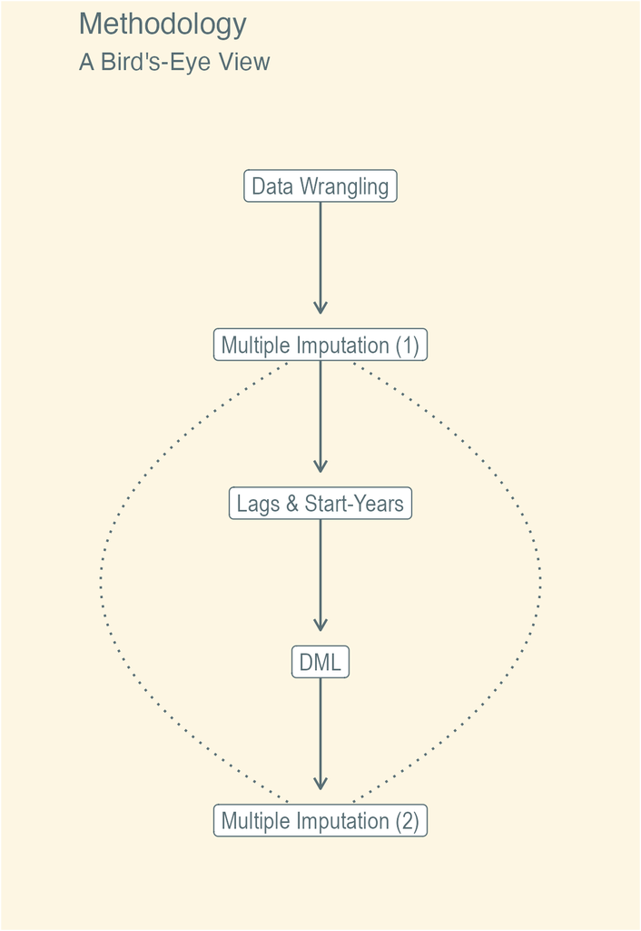

Figure 1: Methodology Flowchart. Note that the final preprocessing steps and DML writ large are nested within the multiple-imputation procedure, which begins with iterative completion of missing data and ends with pooling of results.

### 2.2 Preprocessing

#### 2.2.1 Data Wrangling

##### 2.2.1.1 Outcome & Treatments

Before running the replication and novel models, I assemble a dataset, $\mathbf{S} = [\mathbf{Y \; D \; X}] \in \mathbb{R}^{N \times (1 + q + k)}$, through data wrangling.[^7] First, I retrieve $\mathbf{Y} \in \mathbb{R}^{N \times 1}$—namely, [Human Rights (HR) Scores](https://dataverse.harvard.edu/dataverse/HumanRightsScores) (Fariss et al., 2020), the common outcome of interest. Next, I construct the treatment variables, $\mathbf{D} \in \mathbb{R}^{N \times q}$. This second task is far more involved, one that generally demands significant transformations to the raw data to ultimately render them in country-year (i.e., panel) format. How these treatments are sourced and generated—and how missingness is handled—is discussed further in Section 3.

<sup>7</sup> “Data wrangling” is my preferred designation for basic dataset construction and refinement (e.g., variable aggregation and resolution of coding conflicts).

##### 2.2.1.2 Covariates

Afterwards, I consolidate the covariates, $\mathbf{X} \in \mathbb{R}^{N \times k}$, creating additional ones where necessary. $\mathbf{X}$ is nearly identical across the three chapters, featuring the following common regressors:

1. All 26 Varieties of Democracy [(V-Dem)](https://www.v-dem.net/) high- and mid-level indices.
2. From the [Polity Project](https://www.systemicpeace.org/polityproject.html), Polity and Regime Durability.[^8]
3. World Development Indicators (WDIs) from the World Bank pertaining to:[^9]
   1. Trade.
   2. Foreign direct investment (FDI).
   3. Population density.
4. From Fariss et al. (2022), latent estimates of GDP, GDPpc, and population (logged).
5. Indicators of currency crises and International Monetary Fund (IMF) program membership, as well as balance of payments (share of GDP).
6. Correlated random effects (CREs).

<sup>8</sup> I source these variables from V-Dem and the [Quality of Governance](https://www.gu.se/en/quality-government/qog-data) (QoG) dataset, respectively.

<sup>9</sup> These variables are similarly sourced from the QoG dataset.

Descriptions of these covariates, as well as justifications for and exceptions to their inclusion, are all provided in Section 3.

##### 2.2.1.3 Case Selection & Coding

During the assembly of $\mathbf{S}$, I make several decisions on handling observations featuring missingness in numerous or critical areas and irregular coding attributes. Most of these cases involve (1.) small-nation status, (2.) partial international recognition, and (3.) post-Cold War transitions.

In the first instance, I omit from $\mathbf{S}$ all countries failing to appear in V-Dem, coverage in HR Scores notwithstanding. Constituting the lion’s share of these cases are microstates, as classified by the [Correlates of War (COW) project](https://correlatesofwar.org/). Though this omission comes at the cost of circumscribing my studies’ external validity—namely, to non-microstates—it improves the robustness of my final inferences vis-à-vis future replications. Indeed, V-Dem indices constitute the majority of dimensions in each chapter’s $\mathbf{X}$, meaning conclusions drawn from imputed V-Dem data for microstates would be generally and greatly sensitive to the randomness immanent in the imputation process.[^10]

<sup>10</sup> More on my missingness handling method—multiple imputation—may be found in Section 2.2.2.

<sup>11</sup> A discussion of my spatial models is to be found in Section 2.2.3.

<sup>12</sup> For a discussion of Palestine’s exclusion, see the list’s attendant [case description](http://ksgleditsch.com/data/iisyst_casedesc.pdf).

<sup>13</sup> Only states with accompanying Gleditsch and Ward IDs (i.e., “state numbers”) appear in Fariss et al.’s (2022) data.

<sup>14</sup> The computation of these treatments is outlined in Section 3.2.1 and Section 3.3.1.

Moreover, I omit Palestine in view of complications originating from inconsistent coding patterns. Unlike the foregoing microstates, Palestine is covered in V-Dem. However, its reported scores are disaggregated for much of the post-World War II period, with Gaza and the West Bank treated as mutually-exclusive observations, making it unclear as to how to reconcile these data with the single spatial unit that the source of my spatial data, [Natural Earth](https://www.naturalearthdata.com/), supplies for Palestine.[^11] Equally important, Palestine—failing to satisfy Gleditsch & Ward’s criteria for inclusion in the international system and hence absent from their [List of Independent States (v7)](http://ksgleditsch.com/statelist.html)[^12]—lacks the prerequisite for coverage in Fariss et al.’s (2022) GDP and GDPpc variables,[^13] estimates essential for computing several treatments pre-imputation.[^14] Owing to these theoretical and logistical roadblocks, I abstain from incorporating Palestine into my models, with the understanding that doing so comes at some inferential cost.

Also excluded from my models are a few extinct countries, namely East Germany (formally the German Democratic Republic) and South Yemen (formally the People’s Democratic Republic of Yemen). Each was a communist state that existed post-1977,[^15] my oldest start-year, but that unified with its non-communist counterpart (West Germany and North Yemen, respectively) in 1990 amidst the denouement of the Cold War. The two countries enjoy complete data for HR Scores, Fariss et al.’s (2022) estimates, and virtually all V-Dem covariates, *inter alia*—yet they crucially lack polygons from Natural Earth, which does not offer data on historical geographical boundaries on which to base spatial lags. To guarantee consistency of samples and clarify comparability of results in turn, I opt to ignore East Germany and South Yemen throughout, even for my non-spatial models.

<sup>15</sup> Start years are discussed in greater detail in Section 2.2.4.

A further consideration involving post-Cold War geopolitical reconfigurations is the existence of several discrepancies in case identification—namely, differences across datasets in the coding of continuities between predecessor and successor states. These present challenges for variable collation and subsequent inference; indeed, when joining datasets on country identifiers (e.g., COW codes), the discrepancies may yield unmerited duplicates or missingness, raising doubts over inferential validity in later modeling stages if ignored. To harmonize all inputs of $\mathbf{S}$, I allow decisions adopted by HR Scores and/or V-Dem—the sources of my outcome and the preponderance of covariates—to override alternative coding schemes in the following cases:

1. Czechia: coded as the successor of Czechoslovakia.
2. Germany: coded as the successor of West Germany.
3. Serbia: coded as the successor of Yugoslavia.
4. Yemen: coded as the successor of North Yemen.

These decisions being taken, I arrive at my final set of cases. Ultimately, the maximum number of states featuring in my models is 174. For a full breakdown on these figures, as well as complete itemizations of the excluded and manually-coded cases discussed above, see appendices A (Section 6.1), B (Section 6.2), and C (Section 6.3).

#### 2.2.2 Making Multiply-Imputed Data

The aim of my next step is to handle remaining missingness in $\mathbf{S}$ and hence sample selection bias.[^16] Uncomplicated methods of doing so (e.g., listwise deletion, mean imputation, etc.) are commensurately easy to implement, though these generally rest on the very strong assumption that the data is “missing completely at random” (MCAR), in which case selection bias is unlikely to be a concern of interest; produce unwarrantedly large or small standard errors; or may prove wasteful.[^17] Endeavoring to avoid these pitfalls, I opt for the more resilient method of multiple imputation. Widely regarded as [“the best general method to deal with incomplete data”](https://stefvanbuuren.name/fimd/sec-historic.html) (Van Buuren, 2018), multiple imputation broadly involves the following three steps:

<sup>16</sup> Put simply, this form of bias arises from nonrandom processes causing the likelihood of observations’ inclusion in the sample to vary by individual or group. Left unattended, incomplete data can easily compound such bias, since observations exhibiting missingness are excluded from modeling entirely. In the context of international panel data, if some countries or years are systematically more prone to missingness (e.g., due to uncompliant or unreliable reporting in authoritarian states or conflict zones, or during periods wherein such phenomena are more abundant), then the externally validity of any subsequent findings will inevitably be compromised with respect to those countries or years.

<sup>17</sup> Indeed, listwise deletion would result in the excision of about a third of all my observations per model, as suggested by the data presented in Appendix D (Figure 10). For more on “ad-hoc” solutions to handling missing data, see [Van Buuren (2018)](https://stefvanbuuren.name/fimd/sec-simplesolutions.html).

1. Following a user-specified algorithm estimating the missing values, generating $m > 1$ complete datasets.
2. With each permuted dataset, running user-defined models to estimate some parameter(s) of interest.
3. Under “Rubin’s rules” (see Section 2.4), pooling these estimates to arrive at a single estimate and accompanying variance estimate, performing causal inference accordingly.[^18]

<sup>18</sup> For more on the basics of multiple imputation, see [Van Buuren (2018)](https://stefvanbuuren.name/fimd/sec-nutshell.html).

<sup>19</sup> For more on MCAR, MAR, and MNAR, see [Van Buuren (2018)](https://stefvanbuuren.name/fimd/sec-MCAR.html).

Through this process, multiple imputation provides more realistic standard errors and eschews data wasting. It also need not assume MCAR. Specifically, multiple imputation is equipped to handle data that are both “missing at random” (MAR) and “missing not at random” (MNAR) [(Van Buuren, 2018)](https://stefvanbuuren.name/fimd/sec-idconcepts.html). MAR prevails when MCAR may be assumed conditional on knowing what factor(s) explain the missingness at issue, and thus rests on safer footing than MCAR alone. MNAR, meanwhile, exists when such explanatory factors are unknown.[^19] Carrying out multiple imputation on MNAR data generally requires researchers to assemble more variables explaining the missingness, so as to establish MAR, and/or to conduct an array of sensitivity analyses [(Van Buuren, 2018)](https://stefvanbuuren.name/fimd/sec-sensitivity.html). Lacking obvious evidence of MNAR (particularly after removing the cases described in Section 2.2.1), and guided by the advice that [“[t]he MAR assumption is often a suitable starting point”](https://stefvanbuuren.name/fimd/sec-whenignorable.html) (Van Buuren, 2018), I proceed naively presupposing MAR conditions.

To make multiply-imputed data, I first select $m = 5$. Von Hippel (2009) and White et al. (2011) jointly suggest the following “rule of thumb” when setting $m$: [“the number of imputations should be similar to the percentage of cases that are incomplete”](https://stefvanbuuren.name/fimd/sec-howmany.html) (Van Buuren, 2018). For each chapter and start year, the proportion of observations featuring a missing value is about 30%, suggesting an $m$ in the vicinity of 30. Undercutting this rule of thumb, however, are a few practical difficulties, as [Van Buuren (2018)](https://stefvanbuuren.name/fimd/sec-howmany.html) observes. First, the recommended value of $m$ is likely to be large for datasets with large numbers of variables, and indeed can only increase as dimensions are added, since observations are likelier to feature at least one missing value the more variables they possess. Second—and relatedly—increasing $m$ correspondingly increases the computational and storage costs of the analysis, as each model must be fit on each $\mathbf{m}_{i}$. [Van Buuren (2018)](https://stefvanbuuren.name/fimd/sec-howmany.html) instead recommends setting $m$ to the average missing data rate (i.e., the proportion of values missing from the dataset), or to 5 when computational and storage capabilities are more limited. In fact, the average missing data rate for each chapter and start year is approximately 2%—even when excluding variables that are complete by design, namely the outcome, treatments, and fixed effects—meaning $m = 5$ is more than sufficient under the circumstances.[^20]

<sup>20</sup> For a complete summary of these missing data rates, see Section 6.4.

<sup>21</sup> Technically, this is done by tolerating the default setting $m = 5$.

<sup>22</sup> For a complete enumeration of the imputation methods on offer from `mice`, see [(Van Buuren, 2018)](https://stefvanbuuren.name/fimd/sec-modelform.html). More on the process of and algorithm for tree-based imputation can also be found in [(Van Buuren, 2018)](https://stefvanbuuren.name/fimd/sec-cart.html)

<sup>23</sup> I exclude as predictors all variables wherein the missing-data rate meets or exceeds 10% for the oldest start-year, since including them tended to result in failed imputations. Some variables are exclusive to certain observations and attendant models, as we shall later see (e.g., PTA scores for Global South states), and thus would logically never relate to others (e.g., Global North states), hence why I likewise ignore these. Otherwise, I am permissive, since the main issues with specifying a great number of predictors—“multicollinearity and computational problems” [(Van Buuren, 2018)](https://stefvanbuuren.name/fimd/sec-modelform.html)—are effectively neutralized by my use of random forests (a multicollinearity-robust learner, as mentioned in Section 2.3.4.2) and parallel processing. As a final remark, note that among the variables I mark as predictors is HR Scores, the main outcome, a step explicitly recommended by [Van Buuren (2018)](https://stefvanbuuren.name/fimd/sec-modelform.html).

<sup>24</sup> Pooling is limned at length in Section 2.4.

Next, I avail myself of [`mice::futuremice`](https://amices.org/mice/reference/futuremice.html), which permits users to generate each $\mathbf{m}_{i}$ in parallel across individual CPU cores, significantly quickening computation time. In addition to setting $m$,[^21] I further specify the imputation method and predictors. As to the former, I choose random forests, a flexible learner equipped to handle both numeric and categorical data.[^22] As to the latter, for any given chapter, I mark all fully- and greatly-complete variables common to every model as predictors, following the “general rule” of “using every bit of available information [in order to yield] multiple imputations that have minimal bias and maximal efficiency” [(Van Buuren, 2018)](https://stefvanbuuren.name/fimd/sec-modelform.html).[^23] Finally, I set a seed to ensure reproducibility. Implementing `futuremice` with these arguments ultimately yields five completed iterations of $\mathbf{S}$: $(\mathbf{m}_{i})_{i=1}^5$. It is from these iterations that I conduct all remaining work, pooling the results obtained from each $\mathbf{m}_{i}$ in the final stage.[^24]

#### 2.2.3 Spatial Lagging

In each chapter, I run two sets of models: one predicated on country-year fixed effects, the other on spatial econometrics. My preliminary plans for models drawing from this tradition are discussed in my prospectus, specifically as regards chapters 2 and 3; but at this juncture, it’s imperative to elaborate not only on why I’ve instead implemented spatial models for all three chapters, but also on the specific spatial model I’ve chosen.

The cardinal aim of spatial-econometric models is to enable scientists to control for spatial dependencies between observations in geographically-structured data, where traits of unit $x$ may correlate with or affect those of neighboring unit $y$ and perhaps vice versa. In such contexts, these dependencies may promote omitted-variable bias (OVB), jeopardizing valid inference.[^25] The data at my disposal—country-year panel data—manifestly feature a geographical dynamic, with some observations being spatially nearer to or farther away from others. In addition, spatial dependencies, irrespective of the mechanism(s) producing them,[^26] have been observed in country-year data in sundry dimensions. These include poverty, inequality, corruption, pollution, levels of democracy and wealth, and policy emulation more generally (Ward & Gleditsch, 2008, pp. 2-11).[^27] The ubiquity of spatial dependencies in country-year data and the hazard they pose to valid inference jointly merit, in my view, the application of spatial models wherever such data is of interest—that is, throughout my dissertation—at least as a supplement to traditional, non-spatial methods.

<sup>25</sup> Heuristically, OVB occurs when confounders are left uncontrolled, exacerbating endogeneity (i.e., correlation between treatments and the error term) and hence the prospect of spurious inference. Therefore, spatial dependencies—factors that, by definition, may influence treatment assignment or degree—can contribute to OVB if ignored. For more on the relationship between spatial dependence and OVB, see Gilbert et al. (2024, p. 6) and Rüttenauer (2024, p. 6), for example.

<sup>26</sup> These may include spillovers or clustering (whether explained or unexplained) of outcomes, covariates, or unobservables (i.e., the error term). For more on these potential mechanisms, see Cook et al. (2023, p. 62).

<sup>27</sup> For additional examples of spatial dependencies in country-year data, see Cook et al. (2023, p. 62) and Wimpy et al. (2021, p. 723).

<sup>28</sup> For more on the popularity of SAR, see Rüttenauer (2024, p. 7).

Ultimately, I select the spatially-lagged X (SLX) model over other candidates. I do so motivated by recent literature on spatial econometrics for the social sciences, including Rüttenauer (2022; 2024) and Wimpy et al. (2021), which foregrounds the advantages SLX enjoys over its counterparts—particularly the spatial autoregressive (SAR) model, overwhelmingly the most common implementation of spatial lags.[^28]

The SAR model, which incorporates an endogenous, spatially-lagged form of the outcome ($y$) as a covariate, gives way by design to system-wide “global effects”: effects beyond first-order (i.e., nearest) neighbors, where an original unit’s $y$ affects not only its first-order neighbor’s $y$, but also the neighbor of the first-order neighbor’s $y$ (and so on); and feedback effects, where changes in $y$ in both high- and first-order neighbors return to impact the original unit’s $y$. The upshot of these global effects is that they complicate inference. On the one hand, they preclude interpretation of coefficients as ordinary marginal/partial effects, or how a one-unit change in $x$ impacts $y$, *ceteris paribus*: both direct ($x_{i} \rightarrow y_{i}$) and indirect ($x_{i} \rightarrow y_{j}$) effects differ in value from the coefficients, a function of the feedback loops embedded in the spatial multiplier matrix, meaning said coefficients cannot be interpreted as simple $x \rightarrow y$ relationships in either sense. On the other, the assumption of global dependence is not invariably appropriate: some spatial processes may not extend to the entire system (e.g., the international level, which regional clustering of democracy, wealth, and other variables generally suggests),[^29] or may take time to become fully realized, despite that SAR diffuses global effects exactly at time $t$.[^30]

<sup>29</sup> Indeed, Wimpy et al. find that global dependencies are “relatively rare in political science” (2021, p. 737).

<sup>30</sup> For more on the implications of SAR’s construction, including mathematical proofs thereof, see Rüttenauer (2022, pp. 731-736; 2024, pp. 11-14), and Wimpy et al. (2021, pp. 723-724).

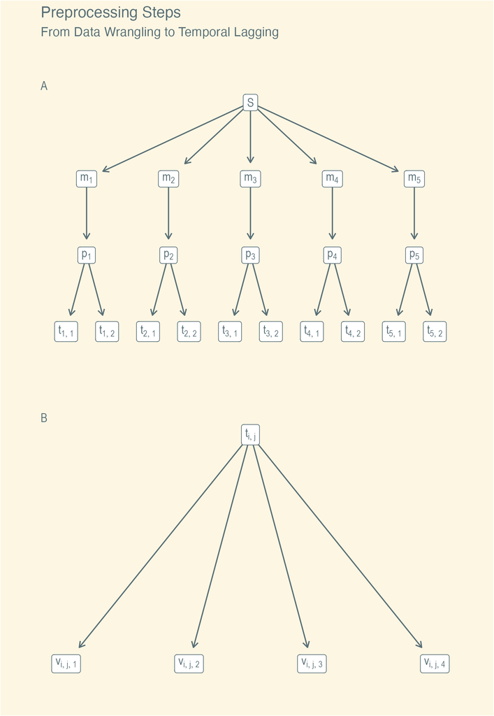

Figure 2: Preprocessing Flowchart

By contrast, the SLX model is highly flexible and easy to interpret. It begins with the more conservative assumption of local dependence (i.e., relationships between first-order neighbors), though researchers may still account for more global (i.e., higher-order) dependencies should they desire to do so. Also, by eschewing global dependence as a starting point, SLX is better suited for panel data, where spatial spillovers at time $t$ may be confined to first- or low-order neighbors. Global effects being absent by default, SLX models need not entail feedback loops, enabling coefficients to be interpreted as ordinary, OLS-like marginal effects.[^31] Equally beneficial, SLX is fit for a wide range of inferential techniques, including machine-learning methods, since it merely involves introducing the spatial lags as an additional set of covariates. Finally, Rüttenauer (2022) and Wimpy et al. (2021) find that SLX is relatively robust to misspecifications of the spatially-dependent covariates.[^32] In view of these advantages, the authors posit that SLX is an apt starting point for model building, particularly absent strong theory implying that a different spatial model would be more appropriate (e.g., a valid belief in global contagion effects, in which case SAR would indeed be suitable).[^33]

<sup>31</sup> This point is stressed by Rüttenauer (2022, p. 735).

<sup>32</sup> For more on their findings, see Rüttenauer (2022, p. 749) and Wimpy et al. (2021, p. 737).

<sup>33</sup> The advantages of SLX are elegantly summarized in Rüttenauer (2024, p. 23) and Wimpy et al. (2021, p. 725).

<sup>34</sup> Formula taken from Wimpy et al. (2021, p. 724).

SLX is of the basic form:[^34]

$$\mathbf{Y} = \mathbf{X}\boldsymbol{\beta} + \mathbf{WZ}\boldsymbol{\theta} + \epsilon$$

Above, $\mathbf{Y}$ is the outcome, $\epsilon$ the error term, $\mathbf{X}$ the matrix of independent variables, $\boldsymbol{\beta}$ the corresponding coefficients, $\mathbf{W}$ the matrix of first-order neighbor weights, $\mathbf{Z}$ the matrix of covariates (or confounders) expected to have a spatial influence, and $\boldsymbol{\theta}$ the spatial coefficients,[^35] capturing spillover effects from $\mathbf{Z}$ covariates on the outcome.[^36]

<sup>35</sup> Wimpy et al. label $\mathbf{X}$ and $\mathbf{Z}$ differently to convey that their contents may vary (2021, p. 724). For example, $\mathbf{X}$ may contain both the treatment(s) and covariates, whereas $\mathbf{Z}$ may contain the latter, exclusively.

<sup>36</sup> More on interpreting the SLX formula may be found in Rüttenauer (2024, p. 8).

<sup>37</sup> That is, a two-dimensional matrix wherein each row sums to 1.

<sup>38</sup> This matrix depiction is taken from Rüttenauer (2024, p. 3).

$\mathbf{W}$, an $N \times N$ row-normalized matrix,[^37] is of especial importance, containing the base information needed to compute the “spatial lags”—versions of each covariate from $\mathbf{Z} \in \mathbb{R}^{N \times v}$ that take the mean of any given observation’s neighbors, and the inclusion of which ultimately makes for an SLX model. Together, $\mathbf{WZ}$ denote the spatial lags. $\mathbf{W}$ is of the form:[^38]

$$\mathbf{W} =
\begin{bmatrix}
w_{1,1} & w_{1,2} & w_{1,3} & \ldots & w_{1, n} \\
w_{2,1} & w_{2,2} & w_{2,3} & \ldots & w_{2, n} \\
w_{3,1} & w_{3,2} & w_{3,3} & \ldots & w_{3, n} \\
\vdots & \vdots & \vdots & \ddots & \vdots \\
w_{n,1} & w_{n,2} & w_{n,3} & \ldots & w_{n, n}
\end{bmatrix}$$

Here, each $w_{i,j}$ element of $\mathbf{W}$ gives the proportion of any given unit’s neighbors one must consider in computing the spatial lags. As a simple yet relevant example, consider a country-year dataset comprising three countries—$i$, $j$, and $k$—and a single covariate, such that $\mathbf{Z} = z_{v}$. For a select year $t$, let $i$ and $j$ be neighbors, and let $j$ and $k$ be neighbors. The row-normalized neighbor-weight matrix would thus be:

$$\mathbf{W} =
\left[
\begin{array}{c|ccccc}
& i & j & k \\ \hline
i & 0 & 1 & 0 \\
j & 0.5 & 0 & 0.5 \\
k & 0 & 1 & 0
\end{array}
\right]$$

Furthermore, let $z_{v} = (i = 2, \; j = 4, \; k = 7.5)$. The spatial lags at $t$ for countries $i$, $j$, and $k$ on covariate $z_{v}$ are thus found by:

$$\mathbf{W}z_{v}^{\; T} =
\begin{bmatrix}
0 & 1 & 0 \\
0.5 & 0 & 0.5 \\
0 & 1 & 0
\end{bmatrix}
\begin{bmatrix}
2 \\
4 \\
7.5
\end{bmatrix} =
\begin{bmatrix}
4 \\
4.75 \\
4
\end{bmatrix}$$

As aforementioned, researchers leveraging SLX may opt to model spillovers beyond first-order relationships. In this scenario, one need only derive higher-order forms of $\mathbf{W}$ (e.g., $\mathbf{W}^{2}$ for second-order neighbors) and compute the additional spatial lags, allowing for the expanded SLX model:

$$\mathbf{Y} =
\mathbf{X}\boldsymbol{\beta} +
\mathbf{WZ}\boldsymbol{\theta} +
\mathbf{W}^{2}\mathbf{Z}\boldsymbol{\theta}_{2} +
... +
\mathbf{W}^{n}\mathbf{Z}\boldsymbol{\theta}_{n} +
\epsilon$$

Though these higher-order lags are easy to generate, they necessarily entail greater computation and storage costs at the modeling stage. Specifically, introducing more spatial lags increases the number of dimensions for each dataset, hampering fit speed and enlarging file sizes, whilst suggesting the implementation of individual models for each maximum order, $n$. Moreover, as regards my research, scant evidence or theory exists on which to justifiably set $n$ beyond $n = 1$. Finally—and in any case—we may intuitively expect bias to be most threatening at the first order, with spatial dependencies attenuating as $n$ increases. Altogether, these considerations motivate me to restrict my spatial lags to the first order, though doing so does not foreclose the possibility of implementing higher-order lags as robustness checks.

To compute the spatial lags, $\mathbf{WZ}$, I first obtain the spatial data needed to derive the weight matrix, $\mathbf{W}$. This data is sourced from Natural Earth, a public domain map dataset containing polygons for all of the world’s countries and land objects, and accessed through [`rnaturalearth::ne_countries`](https://github.com/ropensci/rnaturalearth). From these polygons, and for every year $t$, I use [`sf::st_distance`](https://r-spatial.github.io/sf/reference/geos_measures.html) to generate an $N \times N$ matrix, wherein each element gives the minimum great-circle distance separating the borders of any two countries. The resultant matrix is structured such that—for countries $i$ and $j$ separated by a minimum distance $d$:[^39]

<sup>39</sup> By default, `st_distance` gives $d$ in meters.

1. $d_{i,i} = 0$ and $d_{j,j} = 0$,
2. $d_{i,j} = 0$ and $d_{j,i} = 0$ when $i$ and $j$ share contiguous borders, and
3. $d_{i,j} > 0$ and $d_{j,i} > 0$ when $i$ and $j$ do not share contiguous borders.

Subsequently, I specify neighbors for the annual country-distance matrices under a binary neighborhood-membership criterion.[^40] Of course, one could define neighbors as a country-pair sharing contiguous borders under a “rook” rule; but doing so is to presume that many countries lacking shared borders (e.g., island states) do not belong to any geographical “neighborhood” and are thus immune to spatial processes. This assumption seems unrealistic, so I adopt the distance-threshold rule of 200 kilometers suggested by Ward & Gleditsch (2007, p. 12) to decide neighborhood membership. Under this criterion, with respect to country $i$, country $j$ qualifies for membership in $i$’s neighborhood if $d_{i,j} \leq 200 \text{km}$. Every neighbor relationship being specified, I derive $\mathbf{W}$ using [`spdep::nb2listw`](https://r-spatial.github.io/spdep/reference/nb2listw.html). With both $\mathbf{W}$ and $\mathbf{Z}$—the common covariates enumerated in Section 2.2.1, as well as any chapter-specific covariates—I compute the spatial lags, relying on [`spdep::lag.listw`](https://r-spatial.github.io/spdep/reference/lag.listw.html) to do so. Finally, I append the lags to each $\mathbf{m}_{i}$, making five expanded imputed datasets, $(\mathbf{p}_{i})_{i=1}^5$, where $\mathbf{p}_{i} = [\mathbf{Y \; D \; X \; WZ}] \in \mathbb{R}^{N \times (1 + q + k + v)}$.

<sup>40</sup> Put differently, under the criterion, country $i$ is classified with respect to country $j$ as either a neighbor (1) or a non-neighbor (0). Ergo, no “partial” neighbor exists.

<sup>41</sup> In essence, this would entail switching the “Multiple Imputation (1)” and “Lags & Start-Years” steps depicted in Figure 1.

<sup>42</sup> For example, for country $i$ with neighbors $j$, $k$, and $l$, and with respect to variable $z$, let $z_{j}$ be missing but $z_{k}$ and $z_{l}$ be non-missing. Using exclusively known data, $\bar{z}_{i} = 0.5(z_{k} + z_{l})$. Should $z_{j}$ be imputed, however, it may enter the mean operation, in which case $\bar{z}_{i} = 0.33(z_{j} + z_{k} + z_{l})$. The second $\bar{z}_{i}$ is likely to resemble the first, provided that $z_{j}$ is not an outlier, since the underlying equations differ only by the presence of $z_{j}$ (as well as corresponding adjustments to the averaging weight).

Importantly, in calculating $\mathbf{WZ}$, `lag.listw` produces `NA` values for lags where at least one neighbor’s information is missing. These values can be handled in one of two ways. On the one hand, they can be imputed directly. On the other, they can be prevented entirely, first by imputing missingness in $\mathbf{Z}$—thus forming $(\mathbf{m}_{i})_{i=1}^5$ (i.e., by following the procedure sketched in Section 2.2.2)—and subsequently by computing $\mathbf{WZ}$ for each $\mathbf{m}_{i}$. The first option—waiting to perform multiple imputation until after forming $\mathbf{WZ}$—generates values without enforcing the spatial constraints imposed by $\mathbf{WZ}$, where each element *must* be an average of the values of country $i$’s neighbors.[^41] Consequently, the imputed figures are much less likely to approximate the mean of country $i$’s non-missing neighbors—a reasonable starting point for estimating the lags—and they may vary significantly by $\mathbf{m}_{i}$. The second option, by contrast, respects $\mathbf{WZ}$’s spatial constraints, computing the lags more-or-less normally—namely, by directly considering known neighbor values, supplementing these inputs with imputations where necessary. As a result, these estimates tend closer to the mean of country $i$’s non-missing neighbors and are therefore more realistic.[^42] To wit, the second method yields more stable, accurate, and theoretically-valid estimates of the lags across each $\mathbf{m}_{i}$. It is clearly preferable, so for each dataset $\mathbf{S}$, I proceed by finding $\mathbf{WZ}$ from imputed datasets $(\mathbf{m}_{i})_{i=1}^5$.

#### 2.2.4 Start-Year Specification

Upon completing the spatial lags, I specify the “start years”—the year at which at each $\mathbf{p}_{i}$ may begin—where necessary. The exact justifications for these start years may be found in Section 3; but at this juncture, a few clarifying points merit mentioning. First, they serve one of two purposes: to align with those adopted by the authors inspiring my work, or to test alternative theories in which another start year may plausibly yield different results. Second, the maximum number of start years set for any given chapter is two: although data availability generally allowed for a third start year beginning before those used by the authors, introducing it in preliminary model testing revealed prohibitive computational costs.[^43] Third, Chapter 3 specifies 1990—exclusively—as the start year, since setting start years more recent than this entails inferential risks.[^44] Ultimately, in specifying start years, there now exist iterations $\mathbf{t}_{i,j}$ for each $\mathbf{p}_{i}$, where $j$ signifies the index number of the start years, ordered chronologically.[^45] In chapters 1 and 2, two start years are specified, such that $j \in \{1, 2\}$. By contrast, Chapter 3 features a single start year, so $j = 1$.

<sup>43</sup> To be precise, running a task with three start years usually led to memory limits being reached, after which the task would fail.

<sup>44</sup> Indeed, because the sample in this chapter is already limited to “Global South” countries, and in consideration of subsequent temporal lagging, a later start year would very likely give way to sample sizes so small that they violate Rubin’s pooling rules.

<sup>45</sup> For example, for Chapter 1, with start years 1977 and 1990, $j \in \{1, 2\}$ corresponds to $\{1977, 1990\}$.

#### 2.2.5 Temporal Lagging

To evaluate whether the treatment effects of interest are delayed,[^46] I perform my final preprocessing step: temporally lagging all independent variables—the treatments ($\mathbf{D}$), covariates ($\mathbf{X}$), and spatial lags ($\mathbf{WZ}$)—for each $\mathbf{t}_{i,j}$ with respect to the outcome ($\mathbf{Y}$). Namely, I lag the independent variables by $t - l$, where $t$ is a given year for any observation of $\mathbf{Y}$, $l$ the number of years prior to $t$ from which values of the independent variables are taken and aligned with $\mathbf{Y}$ at $t$, and $l \in \{1, ..., 4\}$.[^47] Doing so transforms $\mathbf{t}_{i,j}$ to iterations $\mathbf{v}_{i,j,l}$, the ultimate datasets passed through my models.

<sup>46</sup> That is, whether the treatments require certain time spans to elapse before their effects can be realized or detected.

<sup>47</sup> The lower bound of the lags ($l = 1$) is the most basic and common temporal lag employed by social scientists. The upper bound ($l = 4$), on the other hand, seeks to test whether the intended outcome of a policy implemented at the onset of a hypothetical political cycle (e.g., U.S. presidential term) may eventually be realized by its very end.

<sup>48</sup> Specifically, under such conditions, when independent variables are temporally lagged with respect to $\mathbf{Y}$, early observations take on missing values and are effectively dropped as a result. For instance, if the independent variables are lagged by $t - 1$ (i.e., one year), their values for start year $t_{sy}$ appear when $\mathbf{Y}$ is at $t_{sy} + 1$. Because there naturally exist no data at $t_{sy} - 1$ (i.e., the year prior to $t_{sy}$) from which to complete the lag, all independent variables corresponding to $\mathbf{Y}$ at $t_{sy}$ become missing. In the country-year case, this means that for every country, when $\mathbf{Y}$ is at $t_{sy}$, all independent variables are missing, and $N$ is simply reduced by the total number of countries (since one observation per country now features missingness).

Temporal lagging is a typical feature of inferential models, especially those concerned with international policy questions and country-year panel data. Nevertheless, the technique poses a few complications for my research. First, absent extant data preceding the first chosen start year, $N$—the sample size of $\mathbf{v}_{i,j,l}$—inevitably shrinks as $l \rightarrow \infty$.[^48] This is a structural feature of temporal lagging and is not problematic *per se*. However, it merits mentioning that as sample size decreases, so too does quality of subsequent inference—a problem accentuated for more recent start-years (e.g., 1990). For this reason, I am motivated to cap the maximum number of lags at a modest level, such as $l = 4$.

Second is the infeasibility of implementing finite distributed lag models (FDLs). An option available to political scientists interested in spatio-temporal processes,[^49] FDLs attempt to capture cumulative delayed effects ending at time $t$ but beginning at $t - l$ by including both contemporary independent variables ($\mathbf{X}_{t}$) and lagged versions thereof spanning the sequence of discrete time points (e.g., years) from $t - 1$ through $t - l$ ($\mathbf{X}_{t-1}, ..., \mathbf{X}_{t-l}$). For example, in a simple FDL, where $l = 1$:[^50]

<sup>49</sup> A discussion of FDLs and their utility for political-science research may be found in Cook et al. (2023).

<sup>50</sup> For equation, see Cook et al. (2023, p. 64).

$$y_{t} = \beta x_{t} + \gamma x_{t-1} + \epsilon_{t}$$

Here, both $x_{t}$ and $x_{t-1}$ feature in the model, and the cumulative effect of $x$ on $y$ beginning at $t-1$ is found simply by summing the estimates of $\beta$ and $\gamma$.

Typical problems attending FDLs arise from the selection of $l$—an arbitrary, user-defined limit—and multicollinearity (especially as $l \rightarrow \infty$), since each $\mathbf{X}$ is usually highly correlated with its temporal neighbor(s) along the lag sequence.[^51] A more unique complication, however, appears in the context of DML. As we shall soon see (Section 2.3.3), the DML models I deploy partly rely on predicting the treatment itself from the remaining independent variables. FDLs in this paradigm, therefore, inexorably entail utilizing later treatment observations to predict earlier ones. From our previous example, estimating effect $\gamma$ (i.e., the impact of $x_{t-1}$ on $y_{t}$) necessitates computing:

<sup>51</sup> For a brief discussion of these issues, see Mignon (2024, p. 271).

$$x_{t-1} = \beta x_{t} + \epsilon_{t}$$

Nonetheless, modeling $x_{t-1}$ as a function of $x_{t}$ violates an obvious and elementary rule of causality: that cause $x$ must temporally precede effect $y$. Because syntheses of FDLs and DML suggest such impossible event sequences—namely, effects occurring before their causes—the two methods are fundamentally incompatible. I proceed, then, by forgoing the use of FDLs, finding treatment effects at each $t-l$ independently (i.e., for each $\mathbf{v}_{i,j,l}$), though doing so admittedly precludes the potential for further investigation into cumulative effects.

### 2.3 Double/Debiased Machine Learning (DML)

#### 2.3.1 Summary

After preprocessing my data, I turn to the task of carrying out my DML models. The following section aims to delineate the motivations, architecture, and ultimate decisions for these models, discussing:

1. Causal inference with machine learning and DML in general (Section 2.3.2)
2. Partially-linear regression (PLR), basic DML, my initial design choices, and noteworthy implications thereof (Section 2.3.3)
3. Learner selection (Section 2.3.4): the considerations (Section 2.3.4.1) informing my final decisions (Section 2.3.4.2)
4. Final fits (Section 2.3.5.3), generally informed by cluster-robust DML (Section 2.3.5.3.1), but ultimately undertaken using my novel buffered cluster-robust (BCR) procedure (Section 2.3.5.3.2)
5. Stacking (Section 2.3.5.4)

#### 2.3.2 Introduction

Machine learning (ML) generally describes the study, design, and application of statistical models that receive and make sense of data to deliver predictions.[^52] Though motivated in the first instance to optimize predictive accuracy, ML methods have become increasingly attractive to researchers performing causal inference, including social scientists. First, they are diverse and flexible, offering a multiplicity of algorithms and settings underpinned by commensurately-variegated assumptions.[^53] For instance, some learners need not presume linearity in the relationship between the predictors and the outcome (e.g., tree-based), or that all predictors contribute to the outcome (e.g., lasso). Accordingly, ML encourages consideration of a richer assortment of possible causal patterns—some, many, or all of which may be discovered to better-comport with reality, thereby promising insurance against model misspecification and consequent bias.[^54] Second, ordinary least squares (OLS)—the traditional workhouse of causal inference—is known to overfit, especially in the high-dimensional case, where the $P$ number of predictors meets or exceeds the $N$ number of observations (i.e., $P \geq N$).[^55] Conventional models are thus vulnerable to poor external validity, a weakness exposed especially in the prevailing era of “big data,” wherein a greater availability of predictors can—and perhaps should—be considered to defend against researcher bias.[^56] Finally, ongoing advances in computational power render the most demanding ML methods increasingly accessible to ordinary practitioners. The reasons for ML’s allure to contemporary causal researchers are persuasive, in my view, inspiring me to employ machine learners for my own work. Nevertheless, as we shall soon see, simply performing inference with these learners ad hoc—that is, using them “naively”—is a poor substitute. For executing my models, then, I turn to a well-rationalized and comprehensive integration of ML and causal inference known as “double/debiased machine learning” (DML).

<sup>52</sup> Parsimonious-yet-apprehensible definitions of ML are surprisingly hard to identify in the literature, though virtually all sources on the topic stress the centrality of prediction and anterior modeling (e.g., [Applied Machine Learning Using `mlr3` in R](https://mlr3book.mlr-org.com/chapters/chapter2/data_and_basic_modeling.html); Baiardi & Naghi, 2024, p. 213; [Tidy Modeling with R](https://www.tmwr.org/software-modeling); etc.). Some, including Chernozhukov et al. (2024, p. 2) and Kuhn & Johnson (2013, p. 1), also conflate ML with artificial intelligence (AI). However, AI is typically understood to encompasses the entire initiative to replicate human cognitive functions—including pattern recognition, decision-making, and prediction—so it is perhaps more appropriate to characterize ML as an AI subfield. The two categories are related as such in [IBM’s introduction to ML](https://www.ibm.com/think/topics/machine-learning), for example.

<sup>53</sup> Examples of machine learners include elastic net (of which ridge and lasso are special cases), random forests, boosted trees, neural nets, SVMs, ensembles, stacks, and more. The [`mlr3` list of learners](https://mlr-org.com/learners.html) usefully illustrates the immense extent of the methods users may consider.

<sup>54</sup> Chernozhukov et al. (2024, p. 134) adduce the danger of misspecification (i.e., poor approximation of conditional expectation functions) in the OLS paradigm as a major impetus for the consideration of advanced machine-learning methods and, consequently, the genesis of DML. As we shall soon see, the advantages of such learners over OLS is formally clearest for large, high-dimensional datasets, though their utility extends to smaller datasets as well (since results vary greater by choice of learner in this setting), which Hindman (2015, pp. 53-54) points out.

<sup>55</sup> Heuristically, “overfitting” occurs when an overly-complex model (e.g., one featuring an excessive number of predictors) effectively memorizes the idiosyncrasies of a particular finite sample, delivering poor out-of-sample performance as a result. Hindman (2015, p. 49) asserts that overfitting rears its head in political science frequently through “kitchen-sink” regressions, which use not only many predictors, but also many interactions between them. For more on overfitting and the susceptibility of OLS thereto when $P \geq N$, see Chernozhukov et al. (2024, p. 21 & pp. 71-72).

<sup>56</sup> Grimmer (2015) typifies calls for political scientists to leverage “big data” for causal inference.

<sup>57</sup> Note that now $\mathbf{D} \in \mathbb{R}^{N \times 1}$ rather than $\mathbf{D} \in \mathbb{R}^{N \times q}$, a notational adjustment I maintain for the remainder of the section. I do so not only align with the DML literature—wherein $\mathbf{D}$ is almost always discussed as a single treatment—but also to emphasize that even in the multi-treatment case, $\mathbf{D} \in \mathbb{R}^{N \times 1}$ for any computation of $\hat{\theta}_{0}$, since the DML procedure must be implemented on each treatment to find each $\hat{\theta}_{0}$. This point will become clearer towards the end of Section 2.3.3, wherein I elaborate on DML in the multi-treatment case.

<sup>58</sup> For more on the fundaments of DML, see Chernozhukov et al. (2018, pp. C1-C8).

First introduced by Chernozhukov et al. (2018), DML is a growing framework for econometric inference. It involves solving at least two problems—a “main” equation predicting the outcome of interest ($\mathbf{Y} \in \mathbb{R}^{N \times 1}$), and an “auxiliary” one predicting the policy variable of interest itself ($\mathbf{D} \in \mathbb{R}^{N \times 1}$)—in order to obtain an estimate of a true treatment effect ($\hat{\theta}_{0}$ of $\theta_{0}$); hence, it entails “double prediction.”[^57] Furthermore, its chief purpose is to mitigate the regularization and overfitting biases that may occur when ML methods are employed naively to estimate $\theta_{0}$, making the approach “debiased.”[^58] In doing so, DML guarantees surer footing on which ML-based causal inference may embark.

DML is motivated initially by high-dimensional cases, where $\eta_{0}$—the “nuisance parameter” needed to find $\theta_{0}$—is highly complex, usually because the covariate coefficients comprising $\eta_{0}$ are similar to or larger in number than the total observations ($P \geq N$).[^59] Nevertheless, the framework is a general means of achieving valid estimation of $\theta_{0}$, even from datasets where $P < N$. First, these cases may still exhibit high-dimensionality absent a “pre-specified, known parametric model for [$\eta_{0}$]” (Ahrens et al., 2025, p. 3). Indeed, the “true” model for $\eta_{0}$ may be nonparametric or depend on covariates unknown *ex ante*—possibilities especially germane to observational studies. Second, in both high- and low-dimension settings, DML guarantees the flexibility accorded by ML more generally, freeing researchers to estimate $\eta_{0}$ (and with it, $\theta_{0}$) using learners of all kinds, including nonparametric/nonlinear ones.[^60] Last, researchers working with $P < N$ data benefit from knowing they may safely increase $P$ if desired (e.g., for robustness checks) without needing to entertain major model alterations, since DML is already constructed to accommodate $P \geq N$. Therefore, even though $P < N$ for every $\mathbf{v}_{i,j,l}$ at present, DML remains a viable and useful framework for estimating my treatment effects of interest.

<sup>59</sup> The nuisance parameter ($\eta_{0}$) is denominated as such because although it is necessary for obtaining the target parameter ($\theta_{0}$), it is not of direct interest.

<sup>60</sup> For more on this advantage of DML, see Ahrens et al. (2025, p. 4).

#### 2.3.3 Partially-Linear Regression (PLR), Basic DML, & Initial Decisions

The specific DML model I elect to use is the partially-linear regression (PLR) model: it is the most generally appropriate—additional assumptions must be satisfied to justify the use of other DML models (e.g., those built for instrumental variables or static panels)—and is the simplest, making it the easiest to interpret.[^61] *Prima facie*, the partially-linear panel regression model (PLPR) may seem tempting considering the country-year structure of my data; yet in my estimation, the assumptions on which it rests are too restrictive for my research. Most crucially, it requires no feedback to predictors (e.g., last year’s $\mathbf{Y}$ and $\mathbf{D}$ do not affect this year’s $\mathbf{X}$) and a static panel (e.g., knowing this year’s $\mathbf{X}$, this year’s $\mathbf{Y}$ and $\mathbf{D}$ are independent of last year’s $\mathbf{Y}$, $\mathbf{X}$, and $\mathbf{D}$). Although I currently do not model violations thereto directly (e.g., FDLs or LDVs, options discussed in Section 2.2.5), these assumptions seem broadly inappropriate when extended to international policies and behaviors. Indeed, such phenomena are known to persist, transform, and diffuse over time, and to follow flexible causal processes more generally. Accordingly, it is difficult to accept that the histories of $\mathbf{Y}$, $\mathbf{X}$, and $\mathbf{D}$ are even conditionally-orthogonal to the present, rendering PLR a safer starting point.[^62]

<sup>61</sup> PLR is indeed the most basic of the DML models: it is built on two equations, clearly capturing DML’s double-prediction logic, while also being reducible to an easy-to-explain OLS regression (as we shall soon see). PLR thus serves as the paradigmatic model for all introductions to DML.

<sup>62</sup> For more on PLPR and its implementation in `DoubleML`, see Clarke & Polselli (2025) and the [`DoubleML User Guide`](https://docs.doubleml.org/stable/examples/py_double_ml_plpr.html). For a full enumeration of the DML models currently available in statistical software, see the [`DoubleML` User Guide](https://docs.doubleml.org/stable/guide/models.html).

Having decided on PLR, I shall now delineate how it works in the “basic” (i.e., non-cluster-robust) DML setting. I do so because I occasionally operate within it (see Section 3.2.4), but more importantly because cluster-robust variations of DML are mere extensions of the basic case. Indeed, my cluster-robust models ultimately retain the same underlying PLR estimation procedure, the only deviations occurring during resampling and computation of the standard errors. Understanding how PLR ordinarily operates, therefore, is indispensable to understanding how it functions in my final models.

The PLR model is initially of the form:

$$\begin{align*}
\mathbf{Y} = \mathbf{D}\theta_{0} + g_{0}(\mathbf{X}) + \boldsymbol{\zeta}, \qquad \mathbb{E}[\boldsymbol{\zeta}|\mathbf{D},\mathbf{X}] = 0 \\
\mathbf{D} = m_{0}(\mathbf{X}) + \mathbf{V}, \qquad \mathbb{E}[\mathbf{V}|\mathbf{X}] = 0
\end{align*}$$

As before, $\mathbf{Y}$ is the outcome, $\mathbf{D}$ the treatment, $\theta_{0}$ the effect of interest, and $\mathbf{X}$ the covariates. Additionally, $g_{0}$ and $m_{0}$ are the nuisance functions, where $\eta_{0} = (m_{0}, g_{0})$, and $\boldsymbol{\zeta}$ and $\mathbf{V}$ are the stochastic error terms. In the main equation, a user-specified machine learner predicts $\mathbf{Y}$ by estimating $g_{0}$, whereas in the auxiliary equation, another chosen learner predicts $\mathbf{D}$ by estimating $m_{0}$.

As aforementioned, ML estimators are vulnerable to regularization and overfitting biases when used naively. On the one hand, the regularization parameters that ML models ordinarily employ (e.g., $\alpha$ and $\lambda$ in the elastic-net paradigm) may force said models towards simplicity (e.g., shrinking coefficients towards $0$ in lasso and ridge), exacerbating estimation error should they do so erroneously.[^63] On the other, since they are often highly complex and flexible, ML models are prone to virtual memory of training data.[^64] Such learners may then give overfit $\hat{\eta}_{0}$, leading to exceedingly-biased $\hat{\theta}_{0}$ should the data used to find $\hat{\eta}_{0}$ be the same as that used to find $\hat{\theta}_{0}$.[^65] To overcome these forms of bias, DML relies on two techniques: (1.) orthogonalization and (2.) cross-fitting.

<sup>63</sup> The example of “shrinkage bias,” a type of regularization bias, is given in Chernozhukov et al. (2024, p. 74). Also, the danger regularization bias poses for complex, high-dimensional nuisance parameters—the original motivation for DML—is especially salient, as underscored in Bach et al. (2024a, p. 11).

<sup>64</sup> Heuristically, many ML models are deemed “complex” and “flexible” because they offer numerous hyperparameter combinations for users to set. The role of hyperparameters (and tuning thereof) is reviewed in Section 2.3.5.2.

<sup>65</sup> Put differently, say $\hat{\eta}_{0}$ is found on sample $\mathbf{S}$ using a flexible learner and is ultimately overfit, memorizing the “noise” (or statistical patterns) unique to each observation. Then, $\hat{\eta}_{0}$ is used to find $\hat{\theta}_{0}$, also on $\mathbf{S}$. In this scenario, the estimation error of $\hat{\eta}_{0}$—which includes the idiosyncratic noise learnt finding $\hat{\eta}_{0}$—will be correlated with the score function obtaining $\hat{\theta}_{0}$ (e.g., that of PLR), as the latter relies on the former. Therefore, $\hat{\theta}_{0}$ is susceptible to differing greatly from $\theta_{0}$, particularly when unseen data exists absent from $\mathbf{S}$. For additional heuristic descriptions of the consequences of overfitting for DML, see Ahrens et al. (2025, p. 3) and Chernozhukov et al. (2024, pp. 255-256 & 273).

<sup>66</sup> PLR is “partially linear,” then: OLS is mandatory in the final step, but nonlinear (e.g., tree-based) models are permissible to estimate $\eta_{0}$.

<sup>67</sup> The equation here assumes the selection of the standard score function, which does not estimate $g_{0}(\mathbf{X})$ directly, but instead estimates $\ell_{0}(\mathbf{X}) := \mathbb{E}[\mathbf{Y}|\mathbf{X}] = \mathbb{E}[\mathbf{D}|\mathbf{X}]\theta_{0} + g_{0}(\mathbf{X})$ (see the [`DoubleML` User Guide](https://docs.doubleml.org/stable/guide/models.html)). This explains why $\ell_{0}$ now replaces $g_{0}$. Below, I will elaborate on the role of score functions in DML.

The first—orthogonalization—serves to counter regularization bias. In the PLR case, this occurs through the “partialling-out” procedure, whereby the residuals of the main and auxiliary equations are extracted, and the former is regressed on the latter using ordinary least squares (OLS), yielding not only the regression coefficient $\hat{\theta}_{0}$, but also (in non-cluster-robust DML) the accompanying standard error and confidence interval.[^66] Specifically, consider the original PLR equation transmuted to residualized form:[^67]

$$\begin{align*}
\mathbf{Q} = \mathbf{V}\theta_{0} + \mathbf{\zeta}, \qquad \mathbb{E}[\mathbf{\zeta}|\mathbf{D},\mathbf{X}] = 0 \\
\mathbf{Q} = \mathbf{Y} - \ell_{0}(\mathbf{X}), \qquad \ell_{0}(X) = \mathbb{E}[\mathbf{Y}|\mathbf{X}] \\
\mathbf{V} = \mathbf{D} - m_{0}(\mathbf{X}), \qquad m_{0}(X) = \mathbb{E}[\mathbf{D}|\mathbf{X}]
\end{align*}$$

Here, the residuals $\mathbf{Q}$ and $\mathbf{V}$ correspond to $\mathbf{Y}$ and $\mathbf{D}$, respectively, after partialling out (i.e., subtracting) the effect of $\mathbf{X}$ on each. In practice, DML estimates these residuals using the plug-in estimators of the nuisance functions, $\hat{\ell}_{0}$ of $\ell_{0}$ and $\hat{m}_{0}$ of $m_{0}$, initially found by the learners predicting $\mathbf{Y}$ and $\mathbf{D}$:

$$\begin{align*}
\mathbf{\hat{Q}} = \mathbf{Y} - \hat{\ell}_{0}(\mathbf{X}) \\
\mathbf{\hat{V}} = \mathbf{D} - \hat{m}_{0}(\mathbf{X})
\end{align*}$$

$\hat{\theta}_{0}$ is then obtained simply by regressing $\mathbf{\hat{Q}}$ on $\mathbf{\hat{V}}$.[^68]

<sup>68</sup> This explanation of PLR is adapted mostly from Bach et al. (2024a, pp. 7 & 10-12). For an additional simple discussion of PLR, see Chernozhukov et al. (2024, pp. 249-251).

<sup>69</sup> The term “sample analogue” is also referred to in the DML literature as the “empirical analogue.” I use the former term, however, to preserve lexical consistency with earlier discussions involving samples $\mathbf{v}_{i,j,l}$.

<sup>70</sup> See Chernozhukov et al. (2024, pp. 24-25) for more on the FWL Theorem.

<sup>71</sup> This condition may be found in Bach et al. (2024a, p. 12).

The partialling-out operation results in a debiased $\hat{\theta}_{0}$ for two reasons. First, the Frisch–Waugh–Lovell (FWL) Theorem guarantees that it actually gives $\hat{\theta}_{0}$. Namely, since FWL demonstrate that the population regression coefficient, $\theta_{0}$, may be recovered by regressing the true residualized $\mathbf{Y}$ on the true residualized $\mathbf{D}$—that is, $\mathbf{Q}$ on $\mathbf{V}$—it follows that in the sample analogue,[^69] regressing $\mathbf{\hat{Q}}$ on $\mathbf{\hat{V}}$ returns $\hat{\theta}_{0}$.[^70] Second, in obeying Neyman orthogonality, partialling out alleviates regularization bias affecting $\hat{\theta}_{0}$. All DML models estimate $\theta_{0}$ using score functions $\psi(\mathbf{S};\theta,\eta)$ that solve the sample analogue of the moment condition:[^71]

$$\begin{align*}
\mathbb{E}[\psi(\mathbf{S};\theta_{0},\eta_{0})] = 0
\end{align*}$$

Specifically:[^72]

<sup>72</sup> The generic DML estimator is expressed as such in Chernozhukov et al. (2018, p. C8).

$$\begin{align*}
\frac{1}{n}\sum_{i \in I}\psi(\mathbf{S};\hat{\theta}_{0},\hat{\eta}_{0}) = 0
\end{align*}$$

Here, $\mathbf{S} := (\mathbf{Y}, \mathbf{D}, \mathbf{X})$.[^73] The function $\psi$ also obeys the Neyman-orthogonality condition:[^74]

<sup>73</sup> The DML literature typically uses $\mathbf{W}$ to denote the observations, but I use $\mathbf{S}$ to maintain alignment with the notation seen in Section 2.2.1.

<sup>74</sup> The condition is expressed as such in Chernozhukov et al. (2018, p. C8). In Bach et al. (2024a, p. 12), it is writtenn similarly as: $\partial_{\eta}\mathbb{E}[\psi(\mathbf{S};\theta_{0},\eta_{0})]\bigg|^{}_{\eta = \eta_{0}} = 0$

$$\begin{align*}
\partial_{\eta}\mathbb{E}[\psi(\mathbf{S};\theta_{0},\eta_{0})][\eta - \eta_{0}] = 0
\end{align*}$$

Heuristically, this property guarantees that the moment-condition estimator is insensitive to minor deviations of the plug-in nuisance parameter $\hat{\eta}_{0}$ about its true value $\eta_{0}$.[^75] It follows that DML ensures a $\hat{\theta}_{0}$ robust to regularization bias, a common source of such perturbations in ML. In the case of PLR, partialling out indeed implies a Neyman-orthogonal score function. Under the standard approach:[^76]

<sup>75</sup> A more formal definition of the property is that $\partial_{\eta}$, “the Gateaux derivative operator with respect to $\eta$[,] vanishes when evaluated at the true parameter values” (Chernozhukov et al., 2018, p. C8). Additional heuristic explanations of Neyman orthogonality may be found in Bach et al. (2024a, p. 12), Chernozhukov et al. (2018, pp. C8-C9), and Chernozhukov et al. (2024, pp. 107-108), for example.

<sup>76</sup> The function presented here is “standard” insofar as it is the default for PLR computations in statistical software. For more on this score function’s alternative—one that is typically reserved for instrumental-variable models—see the [`DoubleML` User Guide](https://docs.doubleml.org/stable/guide/scores.html). For a proof of its Neyman orthogonality, see Chernozhukov et al. (2024, p. 283).

$$\begin{align*}
\psi(\mathbf{S};\theta,\eta) := [\mathbf{Y} - \ell(\mathbf{X}) - \theta(\mathbf{D} - m(\mathbf{X}))][\mathbf{D} - m(\mathbf{X})]\
\end{align*}$$

Accordingly, PLR provides the same assurance as that on offer from DML models generally: debiased estimates of $\theta_{0}$.[^77]

<sup>77</sup> That the partialling-out operation (i.e., regressing residuals $\mathbf{\hat{Q}}$ on $\mathbf{\hat{V}}$ to obtain $\hat{\theta}$) implies the foregoing score function may not be immediately apparent to the reader. To obviate any misunderstandings, therefore, I offer a simple proof in Section 6.5 demonstrating how the OLS solution to $\hat{\theta}_{0}$ may be recovered from it.

<sup>78</sup> For more on why cross-fitting helps address overfitting, see Chernozhukov et al. (2024, p. 273).

<sup>79</sup> If $\mathbf{S}$ cannot be partitioned evenly into $K$ splits, then $n \approx N/K$. The IID-sample assumption is stated explicitly, for example, in Chernozhukov et al. (2018, p. C22).

The second bias-tackling technique—cross-fitting—handles the problem of overfitting by preventing data leakage, thereby ensuring that the observations used to obtain $\hat{\eta}_{0}$ are independent of those used subsequently to find $\hat{\theta}_{0}$.[^78] In basic DML, the procedure begins by randomly splitting $\mathbf{S}$—an independent-and-identically-distributed (IID) sample—into $K$ folds of observation indices $[N] = \{1,...,N\}$ and of size $n = N/K$, returning index sets $(I_{k})_{k = 1}^{K}$ as well as their complements, $I_{k}^{c} = [N] \backslash I_{k}$.[^79] Next, the learners estimating $\eta_{0}$ (e.g., those finding $\hat{\ell}_{0}$ and $\hat{m}_{0}$, respectively) are fit on training data $I_{k}^{c}$ to return:

$$\begin{align*}
\hat{\eta}_{0,k} = \hat{\eta}_{0,k}(\mathbf{S}_{I_{k}^{c}})
\end{align*}$$

This is performed for each $k \in [K] = \{1,...,K\}$. Finally, $\hat{\theta}_{0}$ is obtained from a user-specified algorithm aggregating evaluations on test data $I_{k}$ that themselves use $\hat{\eta}_{0,k}$. Optionally, the entire operation may be repeated $R$ times, where $r \in [R] = \{1,...,R\}$, in which case the median of parameters $\boldsymbol{\hat{\theta}_{0}}$ is selected as the final causal estimate.[^80]

<sup>80</sup> This explanation is adapted from Ahrens et al. (2025, p. 19), Bach et al. (2024a, pp. 16-17) and Chernozhukov et al. (2018, p. C23). A useful visualization of cross-fitting may also be seen in the [DoubleML YouTube channel](https://www.youtube.com/watch?v=NWEoLe8mZqM).

<sup>81</sup> DML2 is the conventional label in both the literature and software. The alternative algorithm, DML1, obtains $\hat{\theta}_{0}$ by averaging $\check{\theta}_{0,k}$, preliminary estimates of $\hat{\theta}_{0}$ solved at each $k$ fold. DML2 is generally preferred over its counterpart because it tends to behave more stably. For more on the two algorithms, including the recommendation of DML2, see Bach et al. (2024a, pp. 16-17) and Chernozhukov et al. (2018, p. C24).

As aforementioned, the user sets the algorithm aggregating the test-data evaluations. The recommended and software-default algorithm (DML2), which I opt to follow, is of the form:[^81]

$$\begin{align*}
\frac{1}{N}\sum_{k = 1}^{K}\sum_{i \in I_{k}}\psi(\mathbf{S};\hat{\theta}_{0},\hat{\eta}_{0,k}) = 0
\end{align*}$$

Here, each $\hat{\eta}_{0,k}$ is plugged into the moment-condition estimator simultaneously, such that $\hat{\theta}_{0}$ may be found from a single equation conducting all $N$ evaluations.[^82] In the PLR case, this entails:

<sup>82</sup> Put differently, unlike DML1, preliminary estimates $\check{\theta}_{0,k}$ of $\hat{\theta}_{0}$ need not be found first.

1. Extracting residuals $\mathbf{\hat{Q}}_{k}$ and $\mathbf{\hat{V}}_{k}$, themselves found by predicting on observations $I_{k}$ with their corresponding $\hat{\eta}_{0,k}$,
2. Concatenating the residuals such that $\mathbf{\hat{Q}} = (\mathbf{\hat{Q}}_{k = 1}, ..., \mathbf{\hat{Q}}_{K})$ and $\mathbf{\hat{V}} = (\mathbf{\hat{V}}_{k = 1}, ..., \mathbf{\hat{V}}_{K})$,
3. Regressing $\mathbf{\hat{Q}}$ on $\mathbf{\hat{V}}$ with OLS, thus yielding $\hat{\theta}_{0}$ (as well as, in basic DML, the standard error and confidence interval thereof).[^83]

<sup>83</sup> A heuristic description of this procedure is found in Chernozhukov et al. (2024, p. 251).

<sup>84</sup> For more on the appropriateness of different selections of $K$, see Chernozhukov et al. (2024, p. 276).

<sup>85</sup> To clarify, generally speaking, nuisance-function estimates made from smaller training sets are more vulnerable to randomness in the resampling procedure generating said sets.

<sup>86</sup> This rate increase is not perfectly exponential, since sample splitting under $K^{2}$ cluster-robust DML leaves comparatively-smaller training sets, as aforementioned. A clear illustration of this is provided in Section 6.6.

<sup>87</sup> For example, for the very first repetition of buffered country splits in Chapter 1 (and using the same seed), the training-set minimum/maximum size is 40/73 for $K = 5$ yet 82/109 for $K = 10$. I am happy to reproduce this result upon request.

Further set by the user are the numbers of $K$ sample partitions and $R$ cross-fitting rounds. $K = 5$ is the software-default number of folds, and $K \approx 5$ is usually sufficient for medium-sized datasets.[^84] At first blush, this setting would appear to be a suitable starting point for my work, since each $\mathbf{v}_{i,j,l}$ is approximately medium-sized: $N$ is always more than a few thousand but never on the order of tens or hundreds of thousands. As we shall later see, however (in Section 2.3.5.3), cluster-robust (and especially BCR) resampling comes at the cost of reduced training-set sizes, a threat to accurate nuisance-function estimation further exacerbated by small $K$.[^85] Nevertheless, simply picking an arbitrarily-high $K$ as a workaround is imprudent, since computational and time costs invariably increase as $K \rightarrow \infty$. In fact, in the context of two-way cluster-robust/BCR sample splitting, these expenses balloon at a rate near $K^{2}$.[^86] With $K = 10$, a modest increase to the default, virtually all of my models feature effective runtimes of several hours (see Section 6.7) and the high computational costs these normally imply. Yet they remain feasible to tolerate, particularly with the benefit of high-performance computing clusters, and enable clear improvements to training-set shrinkage.[^87] Thus, in the interest of mitigating not only the burden of model execution and replication, but also the risk of excessively-small training sets for my BCR models, specifically, I hew to $K = 10$ throughout.

My selection of $R$, on the other hand, is made almost exclusively in consideration of cost. Although the software default is $R = 1$, I prefer to set $R > 1$ so as to enhance confidence of the inference about $\hat{\theta}_{0}$.[^88] However, increasing $R$ also increases expenses by $R(K)$ (for regular splitting) or $R(K^{2})$ (for two-way cluster-robust splitting). The smallest $R > 1$ number allowing for the ordinary median of $\boldsymbol{\hat{\theta}_{0}}$ to be drawn is $R = 3$;[^89] yet even at this setting (and with $K = 10$), runtimes are regularly several-hours long (see again Section 6.7). Therefore, to access the benefits of repeated cross-fitting whilst limiting costs, I keep $R = 3$ for every chapter.

<sup>88</sup> To be precise, as $R \rightarrow \infty$, one can be surer that the inference about the chosen $\hat{\theta}_{0}$ is not an outlier, as per the Central Limit Theorem.

<sup>89</sup> That is, being the lowest odd number not $1$, $3$ is also the lowest sequence-length for which a middle value can be simply identified to solve the median (rather than meaning two middle values, as is the case for even-numbered sequences).

<sup>90</sup> For more on DML and PLR with multiple treatments, see Bach et al. (2024a, pp. 20-21) and the [`DoubleML` User Guide](https://docs.doubleml.org/stable/guide/se_confint.html). Support in `DoubleML` for simultaneous inference based on multiplier-bootstrapped test statistics is currently unavailable for clustered data (see the following [`DoubleML` for R GitHub Discussion](https://github.com/DoubleML/doubleml-for-r/discussions/190)), hence why such inference does not appear in my robustness checks.

A final remark on PLR is that it is, like all other DML models, compatible with the multi-treatment case. Given a $p_{1}$ number of treatments $\mathbf{D}_{1},...,\mathbf{D}_{p_{1}}$ with estimated effects $\hat{\theta}_{0,1},...,\hat{\theta}_{0,p_{1}}$, DML finds each $\hat{\theta}_{0}$ iteratively in typical fashion, the only departure being that for any $\mathbf{D}$, all remaining treatments are added to covariates $\mathbf{X}$. In the PLR case, this amounts to regressing $\mathbf{\hat{Q}}$ on $\mathbf{\hat{V}}$ for every $\mathbf{D}$, where $\mathbf{X}$ contains all treatments not $\mathbf{D}$.[^90]

Though simple, the multi-treatment procedure merits mentioning for a few reasons. First—and most obviously—it is implemented wherever I appraise multiple treatment effects simultaneously. Second, it underscores a key technical constraint DML imposes, one that limits me to obtaining and reporting effects on the treatments exclusively. Because every $\hat{\theta}_{0}$ must be found individually in DML—indeed, the moment-condition estimator permits only one $\hat{\theta}_{0}$ to be obtained at a time—costs in the multi-treatment case rise at a rate of $R(K)p_{1}$ or $R(K^{2})p_{1}$. It follows that if one were to estimate the effects of not only every $\mathbf{D}$, but also all $P$ covariates of $\mathbf{X}$, costs would rise by $R(K)(p_{1} + P)$ or $R(K^{2})(p_{1} + P)$. So it is that expenses would explode estimating every effect of every dimension for datasets where $p_{1} + P$ is large, such as $\mathbf{v}_{i,j,l}$.[^91] The upshot of any such undertaking is that costs may prove not only hard to justify—runtimes may mushroom to the order of days—but also prohibitive, inasmuch as models may reach memory limits, and thus fail, on even the most high-performing personal computers. Thus, for my project, where the great size of $P$ effectively guarantees such obstacles, finding $\hat{\theta}_{0}$ for every dimension is not merely impractical, but virtually impossible. My choice of DML, then, admittedly implies a major tradeoff: quantity of $\hat{\theta}_{0}$ for quality of $\hat{\theta}_{0}$—that is, effect estimates of all independent variables for debiased estimates of the treatment effects. This is a compromise with which I am comfortable—the treatment effects are of principal interest to my research agenda, after all—but it goes without saying that the inability to produce estimates of all covariates’ effects complicates efforts to elucidate causal pathways, particularly through conventional means (i.e., interpreting the coefficients on each predictor alongside those of the treatments). Theory-building need not be abandoned by accepting this tradeoff, as aforementioned (see Section 1); but it will demand more creativity and humility about what can (and cannot) be known on the basis of my statistical findings alone.

<sup>91</sup> Specifically, for $\mathbf{v}_{i,j,l}$, $p_{1} + P > 100$ or $p_{1} + P > 200$ is typical. Of course, this explosion of costs is especially encumbering in the high-dimensional case ($P > N$), for which DML is originally designed.

#### 2.3.4 Learner Selection

##### 2.3.4.1 Considerations

A cornerstone of DML, as suggested by its very name, is the use of machine learners estimating $\eta_{0}$. These learners are always chosen by the practitioner, largely after contemplating three considerations: (1.) appropriateness, (2.) cost, and (3.) performance.

Central to any appraisal of the first consideration—appropriateness—is an understanding of one’s data. First and foremost, users must know the variable types of the outcomes they specify for the main and auxiliary equations. If the outcome is continuous, they should select a regression learner; but if the outcome is binary, they should opt for a classification learner. Users also benefit from attention to multicollinearity among the predictors, a possibility especially likely in large-$P$ settings. Indeed, some learners are better-equipped to handle highly-correlated predictors than others, such that the former are preferred wherever multicollinearity obtains.

The consideration of cost, on the other hand, is evaluated chiefly with respect to two factors: hardware constraints and user tolerance. As aforementioned, some models may exhaust computer memory, prompting model failure. In many cases, this occurs due to the complexity of the learner itself—particularly at the tuning stage (see Section 2.3.5.2), where an appreciable number of complex fits being performed and stored simultaneously can quickly occupy total memory. Therefore, complex learners may prove strictly prohibitive, in which case simpler learners may be not just desirable, but necessary. Further affected by hardware are runtimes, which decrease on higher-performing computers (e.g., those with many cores), but which may still prove long for complex learners. Here, users must weigh the runtimes they are willing to tolerate, whether they be several-hours long or even days long, especially when accounting for any replications they or others may seek to execute. For those enjoying access to them, high-performance computing clusters—such as [Northwestern’s Quest](https://rcdsdocs.it.northwestern.edu/start/quest/quest-intro.html)—help mitigate or even obviate many of these concerns. Even under ideal conditions, however, where complex learners can complete their tasks successfully, users may encounter long runtimes when availability of nodes or cores are limited, or when schedulers (e.g., [Slurm](https://rcdsdocs.it.northwestern.edu/systems/quest/user-guide/slurm/slurm.html)) assign their jobs low priority.

Performance—the final consideration—is perhaps the most amenable to rigorous assessment. Many of the most common machine learners (e.g., regularized regressions, tree-based methods, neural networks, etc.) plausibly satisfy the DML-optimal convergence rate requirement of $\hat{\eta}_{0}$ to $\eta_{0}$:[^92]

<sup>92</sup> For more on the convergence requirement and the learners that satisfy it, see Ahrens et al. (2025, pp. 17-18), Bach et al. (2024a, pp. 14-15), and Chernozhukov et al. (2018, pp. C25-C26; 2024, pp. 272-273), for example.

$$\begin{align*}
N^{1/4}\parallel \hat{\eta}_{0} - \eta_{0} \parallel_{L^{2}} \; \approx 0
\end{align*}$$

Such learners immediately qualify as possible candidates for practitioners. The guarantee itself, however, only holds asymptotically (i.e., as $N$ increases); it does not imply that learners will give near-identical estimates for finite samples such as $\mathbf{v}_{i,j,l}$.[^93] Hence, in practice, learners may find substantially different $\hat{\eta}_{0}$—and hence $\hat{\theta}_{0}$—for the same inferential task trained on the same data. Additionally, a single learner’s estimates may vary greatly when its settings (e.g., hyperparameters) are modified, or when presented with new data. Absent further refinement and analysis, then, whether or which estimates approximate the truth will be uncertain, jeopardizing the reliability of any inference about $\hat{\theta}_{0}$. To wit, “DML estimates are only as credible as the choice of nuisance estimator”: if $\hat{\eta}_{0} - \eta_{0}$ might be unacceptably large, then $\hat{\theta}_{0} - \theta_{0}$ might be so, too (Ahrens et al., 2025, p. 34).[^94]

<sup>93</sup> For more on the practical limitations of the DML performance guarantee, see Ahrens et al. (2025, p. 26).

<sup>94</sup> Bach et al. similarly aver that “[t]he performance of the final [DML] estimator depends on the predictive performance of the underlying ML method” (2024a, p. 32).

<sup>95</sup> Cross-validation is an operation similar to DML cross-fitting that likewise evaluates fits from training data $I_{k}^{c}$ on test data $I_{k}$. I shall clarify the distinction in depth in Section 2.3.5.2.

<sup>96</sup> The process and import of learner selection based on out-of-sample predictive performance is described in Ahrens et al. (2025, pp. 30-35), Bach et al. (2024b, pp. 9-11), Chernozhukov et al. (2024, pp. 252-253), and the [DoubleML Choice of Learners Guide](https://docs.doubleml.org/dev/examples/learners/py_learner.html).

Fortunately, optimizing this choice is easily achieved by following two procedures: (1.) hyperparameter tuning and (2.) candidate comparison. In the first—which I sketch in far greater detail in Section 2.3.5.2—hyperparameter combinations from a user-defined sample are cross-validated on the data for each part of the nuisance parameter, and those demonstrating the best predictive performance on the test sets are selected for the final DML fits.[^95] In the second, the tuned models are themselves fit as per DML cross-fitting and then compared by their predictive performance on the test sets. From here, users have two options: to identify the best-performing candidate (e.g., overall or per nuisance part) and make causal claims immediately therefrom, or to first aggregate the residuals from each learner and for each nuisance part following an ensemble algorithm such as stacking (see Section 2.3.5.4), forming “super learners” whose predictive performance on the sample will be at least as good as that of the best-performing constituent learner.[^96] Whether for tuning or for candidate comparison, selecting on out-of-sample performance (i.e., the difference between test-set predictions and their actual values) enables users to deliver $\hat{\eta}_{0}$ better approximating $\eta_{0}$. This, in turn, minimizes $\parallel \hat{\eta}_{0} - \eta_{0} \parallel_{L^{2}}$ and the upper bound on the final nuisance estimator’s bias, directly strengthening the credibility of inferences about $\hat{\theta}_{0}$.

Requisite for assessing out-of-sample prediction in either step, importantly, is the selection of performance metric(s). Typical (and usually-sufficient) metrics for regression tasks are mean squared error (MSE) and root mean square error (RMSE).[^97] For classification tasks, on the other hand, users benefit from weighing a wider array of metrics minding not only their research goals (e.g., equally-accurate prediction of both positive and negative cases), but also the composition of their outcome (e.g., balance between positive and negative cases). Ultimately, users have many metrics at their disposal for judging and optimizing model performance. Nevertheless, they should make their decisions thoughtfully, paying especial attention to the metric’s appropriateness and likely utility for their desired task.

<sup>97</sup> Needless to say, for comparative applications (e.g., determining whether the performance indicator for one learner is larger, smaller, or similar to others’), the two metrics essentially convey the same information, insofar as the latter is simply the square root of the former. They are the default performance metrics for `DoubleML` and `mlr3`, respectively. For the former, see the [DoubleML Choice of Learners Guide](https://docs.doubleml.org/dev/examples/learners/py_learner.html). For the latter, see `?mlr3::default_measures()`.

##### 2.3.4.2 Decisions

Guided by considerations of appropriateness, cost, and performance, I choose the two primary regularized-regression learners (lasso and ridge) and two of the most commonplace tree-based learners in the DML literature (random forests and boosted trees).[^98] Below, I shall justify these selections. Though I ultimately opt to form a super learner from these “base” learners following the short-stacking algorithm, I shall detail why and how I do so later (Section 2.3.5.4), since short-stacking concludes the full DML operation and is thus best understood after becoming acquainted with its anterior procedures.

<sup>98</sup> As they are well-established and exceedingly commonplace in econometric, machine-learning, and other research and applied settings, the candidate learners considered herein will not be described in depth. That is, cursory research should normally suffice to locate the *ad rem* algorithms and procedures. As to ridge, lasso, and elastic net, however, the author submits Hastie et al. (2017, pp. 61-73) and the [`glmnet` Vignette](https://glmnet.stanford.edu/articles/glmnet.html) as useful theoretical and practical primers.

###### 2.3.4.2.1 Regularized-Regression Learners

**(1.) Appropriateness.** Since my treatments (i.e., auxiliary-equation outcomes) are either continuous or binary,[^99] lasso and ridge—as with most qualifying machine learners—are minimally appropriate, being compatible with both regression and classification tasks.[^100] Additionally—and more vitally—lasso and ridge are suitable for multicollinear environments, such as datasets $\mathbf{v}_{i,j,l}$, which indeed feature highly-correlated predictors (e.g., the V-Dem indicators, covariates $\mathbf{X}$ and spatial lags $\mathbf{WZ}$, etc.). Specifically, these regularized-regression learners are empowered to shrink the coefficients of correlated features. To do so, lasso may perform feature selection, shrinking these coefficients all the way to $0$, whereas ridge may shrink them towards each other, to but never at $0$.[^101] In theory, ridge should outperform lasso when multicollinearity prevails. Indeed, when presented with both highly-correlated predictors and changing model specifications (e.g., new training data during cross-fitting), lasso’s choices tend to vary, raising the likelihood of inconsistent estimates. Ridge, meanwhile, permits all features to contribute to their prediction task in some form, in which case their joint influence on the outcome should be more similar fit-to-fit.[^102] Because the true data-generating process (DGP) for my samples is unknown, however, it is also unknown which model will generally perform better *ex ante*. Allowing that lasso may be found to outperform ridge, I proceed agnostically, running my models using each respective learner.

<sup>99</sup> Recall that HR Scores, a continuous variable, is the outcome of interest for each chapter. This means that every main equation features a continuous outcome.

<sup>100</sup> Lasso and ridge, specifically, may execute either task by setting the algorithm as linear for the former or logistic for the latter.

<sup>101</sup> For more on the basic behavior of lasso and ridge given multicollinearity, see the [`glmnet` Vignette](https://glmnet.stanford.edu/articles/glmnet.html).

<sup>102</sup> Ridge’s general superiority over lasso in the multicollinear setting is especially true when $N > P$ (e.g., for datasets such as $\mathbf{v}_{i,j,l}$). For more on the limitations of lasso and advantages of ridge vis-à-vis multicollinearity, see Hastie et al. (2015, p. 56) and Zou & Hastie (2005, p. 302).

<sup>103</sup> Specifically, elastic-net models usually tune for both $\alpha$ and $\lambda$, whereas ridge ($\alpha = 0$) and lasso ($\alpha = 1$) models may only tune $\lambda$. Tuning grids are discussed in greater detail in Section 2.3.5.2.

<sup>104</sup> To be precise, low-resolution tuning grids entail a smaller number of tuning fits and *ipso facto* shorter runtimes.

**(2.) Cost.** Regularized-regression learners such as lasso and ridge are relatively inexpensive. First, they enjoy fast runtimes and occupy little memory, since each estimate need only rely on a single solution to a least-squares optimization problem. Second, they are easy to tune. Indeed, the maximum number of hyperparameters that any of these learners may tune is $2$—though only $1$ for lasso and ridge—such that one may reasonably capture the spectra of possible hyperparameter values (and their combinations, where applicable) with lower-resolution tuning grids.[^103] This, in turn, means regularized-regression learners promise quick runtimes and lower-memory usage still further.[^104] By contrast, tree-based learners, which handle multicollinearity at least as well as lasso and ridge (see Section 2.3.4.2.2), are far more costly. On the one hand, to produce a single estimate, tree-based learners must aggregate the results of hundreds or thousands of fitted trees, a procedure necessarily entailing larger time and memory expenses. On the other, a higher number of hyperparameters demand (or are available for) specification and ought to be tuned accordingly; for example, following recommendations set forth in Bischl et al. (2023), [`mlr3`](https://mlr3tuningspaces.mlr-org.com/index.html) gives default tuning spaces of $4$ and $8$ hyperparameters, respectively, for random forests and boosted trees. Higher-resolution tuning grids are thus essential, compounding already-great time and memory requirements.[^105] Ultimately, these costs proved prohibitively expensive on my personal computer: model failure due to memory limits being reached was unavoidable, even at the tuning stage. As such, I first run the batch of models deploying regularized-regression learners, since it is the easiest to complete immediately.

**(3.) Performance.** The regularized-regression learners, as we have already seen, are equipped to handle multicollinearity, meaning it is reasonable to expect that tuned lasso and ridge models will perform competitively in estimating $\eta_{0}$ (and thus $\theta_{0}$) given datasets $\mathbf{v}_{i,j,l}$. Additionally, we may expect lasso and ridge to perform especially well for nuisance-part functions that are more nearly linear, since both are fundamentally linear algorithms. Finally, between the two, we may anticipate that ridge will perform the best, given its aforementioned stabler tendencies in the multicollinear setting.

###### 2.3.4.2.2 Tree-Based Learners

**(1.) Appropriateness.** Random forests and boosted trees are commonly-used tree-based learners, appearing frequently alongside lasso and ridge in the DML literature.[^106] Like the regularized-regression learners, random forests and boosted trees can solve regression or classification tasks and are hence minimally appropriate. More importantly, tree-based learners, which randomly select features to inform their decision rules, virtually guarantee that only subsets of highly-correlated predictors contribute to any given tree; as such, their predictions are robust to multicollinearity.[^107] There exists no reason to expect either random forests or boosted trees to perform better in the multicollinear-setting, so I run my models without prioritizing one over the other.

<sup>106</sup> Clear examples of this are Ahrens et al. (2025b) and Bach et al. (2024b).

<sup>107</sup> For more on this strength of tree-based learners, see [Kuhn & Johnson (2019)](https://feat.engineering/11-Greedy_Search_Methods.html#sec-recursive-feature-elimination), for instance.

<sup>108</sup> Parallelization is discussed further in the following section (Section 2.3.5.1).

**(2.) Cost.** As aforementioned (see Section 2.3.4.2.1), the chief drawback of tree-based models are the large expenses they normally demand. Fortunately, I am able to overcome any prohibitive limitations these costs impose with my access to Northwestern’s high-performance computing cluster, Quest. In brief, Quest allows users to parallelize tasks across not only cores, but also the nodes (i.e., individual computers) accommodating them.[^108] Accessing high-performance computing, then, I can raise effective memory limits and lower overall runtimes dramatically, rendering tree-based models feasible to implement.

**(3.) Performance.** As we have already seen, tree-based learners handle multicollinearity and can thus be expect to perform well on my data. Also, these learners are highly-flexible and thus capable of capturing relationships both simple and complex, including nonlinear ones. Therefore, we may reasonably expect random forests and boosted trees to perform well generally, but especially for nonlinear nuisance-part functions.

#### 2.3.5 Fits

##### 2.3.5.1 Software & Hardware

Having chosen my learners, I proceed with tuning and fitting my DML models. These tasks are accomplished using software I select following careful deliberation and on the hardware at my disposal.

Presently, there exist two comprehensive open-source DML packages: [`EconML`](https://www.pywhy.org/EconML/) and [`DoubleML`](https://docs.doubleml.org/stable/index.html). Whereas `EconML` is built for business applications whose main estimands of interest are individual-level causal responses, `DoubleML` is optimized for inference on population-wide treatment effects (e.g., the goal of academic research such as mine).[^109] Also—and perhaps more significantly—whereas `EconML` is exclusive to Python, `DoubleML` is available in both Python and R. In this regard, `DoubleML` is more flexible, allowing users comfortable with each language to pivot between versions if desired or needed (e.g., to take advantage of features offered in one but not both, or to seek improved performance from switching). For these reasons—and since R is my primary statistical programming language—I opt to work with `DoubleML`, deeming it to be the safer, more suitable choice for me personally.

<sup>109</sup> See the [`EconML` User Guide](https://www.pywhy.org/EconML/spec/overview.html) for more on its areas of emphasis. `DoubleML` can perform some inference on heterogeneous treatment effects, but only in Python. For more on this, see the [`DoubleML` User Guide](https://docs.doubleml.org/stable/guide/heterogeneity.html).

<sup>110</sup> For example, the `glmnet` package, which `mlr3` uses to execute regularized regressions, automatically performs covariate and dependent-variable standardization, $\lambda$-sequence generation, and coefficient reverse standardization. For more on these built-in capacities, see the [Introduction to `glmnet`](https://glmnet.stanford.edu/articles/glmnet.html#commonly-used-function-arguments) page.

<sup>111</sup> Specifically, during tuning for the main DML equation in Chapter 3 (i.e., with HR Scores as the outcome), I observed a huge disparity between `mlr3`and `scikit-learn` with respect to their best MSEs. This occurred even though I attempted to manually replicate in Python the automated steps performed by `mlr3` and its dependencies. Of course, the writer must acknowledge, here, that the observed poor performance of `scikit-learn` might have resulted from user error, not any deficiencies of the library *per se*. I have not saved the Python results, but I can supply them if requested, since I did retain the original scripts.

<sup>112</sup> Again, I did not save the former runtimes directly, but I can reproduce them if necessary with the Python scripts I kept.

Coding initially with the R version, I intermittently experimented with Python’s as well. Eventually, however, I settled on R’s for all remaining work by reason of user-friendliness, performance, and speed. First, between [`scikit-learn`](https://scikit-learn.org/stable/) and [`mlr3`](https://mlr3.mlr-org.com/)—the main dependencies for `DoubleML` in Python and R, respectively—the latter offered the more streamlined experience, its own dependencies automatically handling a variety of necessary and performance-enhancing preprocessing, pre-tuning, and post-fitting tasks.[^110] Second—and likely relatedly—`mlr3` performed far better than `scikit-learn` in preliminary tests, despite my efforts to align their respective workflows.[^111] Finally, the runtimes in Python and R were effectively the same, meaning continued (and time-costly) efforts to improve the performance of the Python models stood to yield no patent benefits.[^112] `DoubleML` in R, then, emerged as the more sensible choice for my work, providing ease of use and performance safety without sacrificing much—if any—speed.

Influenced by both software and hardware considerations are additional pivotal decisions—namely, whether and how to implement parallel processing. As we have seen, a major drawback of DML involves the high time costs that it (and machine learning more generally) oftentimes implies. Mitigating this problem to a considerable degree, thankfully, is parallel processing, a procedure we have already encountered in Section 2.2.2 and Section 2.3.4.2.2. In brief, parallel processing for a single computational task (e.g., model) divides work across a user-specified number of CPU cores. Similarly, on a high-performance computing cluster such as Quest, entire tasks may themselves be apportioned across core-bearing nodes. In either case, task parts or entire tasks are then run concomitantly, enabling dramatic runtime reductions relative to tasks completed sequentially on a single core or computer. Owing to `mlr3`’s compatibility with software such as the [`future`](https://future.futureverse.org/) package, parallelization for single models is readily achievable in `DoubleML` for R.[^113] Additionally, with Quest, I can assign multiple models to multiple nodes simultaneously, cutting expenses still further. Enjoying access to both of these conveniences, I duly exploit them, not only making computational costs tolerable, but also expanding the pool of candidate learners from which I may realistically select (e.g., to tree-based ones).

<sup>113</sup> Parallel processing is also possible in `DoubleML` for Python through the [`Joblib`](https://joblib.readthedocs.io/en/latest/) library. For more on parallelization with `mlr3`, see [Applied Machine Learning Using `mlr3` in R](https://mlr3book.mlr-org.com/chapters/chapter10/advanced_technical_aspects_of_mlr3.html#sec-parallelization).

<sup>114</sup> More precisely, Quest possesses more than 1200 nodes and more than 80,000 cores. For more, see [Quest’s technical specifications](https://www.it.northwestern.edu/departments/it-services-support/research/computing/quest/specs.html).

As to hardware, specifically, I run my regularized-regression models initially on my personal computer, a MacBook Pro (2024) running on the Apple M4 Pro chip, 24 GB of memory, and 12 cores (8 performance and 4 efficiency). These specifications are worth mentioning for a few reasons. First, my machine was able to handle my most demanding batches of regularized-regression models within the span of approximately 24 hours. As such, those wishing to replicate the results thereof on more-powerful systems may be able to do so quicker, but those working with less-powerful ones should anticipate even longer runtimes. Second, though relatively powerful as a personal computer, my machine proved unable to complete my models when instructed to utilize more complex learners, such as tree-based ones, as I recount in Section 2.3.4.2. Therefore, all my tree-based models are run on Quest, which encompasses a massive number of nodes and cores and is thus easily capable of performing my requested work.[^114] Last, it should be noted that I eventually run my regularized-regression models on Quest, too, to take advantage of the runtime reductions furnished by node-level parallelization.

##### 2.3.5.2 Hyperparameter Tuning

In Section 2.3.4.1, I explain why confidence in $\hat{\theta}_{0}$—DML’s estimate of the true treatment effect, $\theta_{0}$—depends greatly on learner performance. To optimize performance and thus inference, many DML experts argue that an operation common to most machine-learning applications should in fact be “required” of practitioners: hyperparameter tuning (Bach et al, 2024b, p. 2).[^115] Heeding their advice, I subject all my models to the procedure. It is the first step they undergo, and it is the most time-intensive due to the relatively large number of fits quality tuning tends to demand.

<sup>115</sup> The import of hyperparameter tuning to quality inference is underlined further in other guides to DML, such as Ahrens et al. (2025, pp. 34-35) and Bach et al. (2024a, p. 32).

<sup>116</sup> Succinct definitions of hyperparameters may also be found in [Applied Machine Learning Using mlr3 in R](https://mlr3book.mlr-org.com/chapters/chapter4/hyperparameter_optimization.html) and [Tidy Modeling with R](https://www.tmwr.org/tuning).

<sup>117</sup> In basic DML, this entails deriving $\hat{\eta}_{0,k}$ from $I_{k}^{c}$, subsequently evaluating the former on $I_{k}$.

To review, most machine learners incorporate one or more “hyperparameters,” values users must set but cannot estimate directly from the data.[^116] Rather than arbitrarily setting these values and hoping for high-performance to follow, they may instead proceed more methodically, evaluating automatically-drawn candidates of value combinations in a process called “tuning.” Typically, users will define a tuning grid comprised of four essential features: (1.) the hyperparameters to tune; (2.) the resolution, or the number of value combinations to evaluate; (3.) the space, or the ranges from which to sample values; and (4.) the search strategy, or the value-sampling method. They will also specify the number of folds (e.g., $K$ or $K^{2}$) to randomly partition their data. Finally, they will perform “cross-validation.” Similar to cross-fitting (see Section 2.3.3), the procedure first fits learners on training data to obtain an estimate of the nuisance parameter, with which the learners are subsequently evaluated on test data.[^117] Aggregated instead of the out-of-sample residuals, however, is out-of-sample performance, following a user-specified algorithm and performance metric. This operation is repeated for every combination in the tuning grid, after which the candidate demonstrating the best observed performance is chosen for final fitting. In DML, hyperparameter tuning is also usually repeated for every main and auxiliary equation, meaning the entire process is carried out at least twice for any given model.

My own hyperparameter tuning, using the notation of basic DML, may thus be generalized as follows:

1. For each $\mathbf{v}_{i,j,l}$, randomly split the data into $K$ folds.
2. For each DML equation estimating a part of nuisance parameter $\eta_{0}$ (e.g., $\ell_{0}$ or $m_{0}$):
   1. Define a tuning grid with resolution $N$ and a search strategy.
   2. For each hyperparameter combination $n \in [N]$:
      1. Fit the candidate on $I_{k}^{c}$ to obtain an estimate of the nuisance part (e.g., $\hat{\ell}_{0,k}$ or $\hat{m}_{0,k}$).
      2. With the nuisance-part estimate, evaluate the learner on $I_{k}$.
      3. Record the performance according to a user-specified metric.
      4. Repeat for $k \in [K]$.
      5. Aggregate the performance scores according to a user-specified algorithm.
   3. Compare the aggregated scores, and select the best-performing candidate.

As we shall soon see (Section 2.3.5.3.2), the majority of my models follow not basic but two-way buffered cluster-robust DML. Even so, tuning occurs in virtually the same manner, the only difference being the sample-splitting procedure, which forms $K^{2}$ neighbor- and cluster-wise disjoint folds.[^118]

<sup>118</sup> Specifically, in this non-basic setting, $K \rightarrow K^{2}$, $I_{k} \rightarrow I_{k} \times J_{\ell}$, and $I^{c}_{k} \rightarrow ([N] \backslash I^{b}_{k}) \times ([M] \backslash J_{\ell})$.

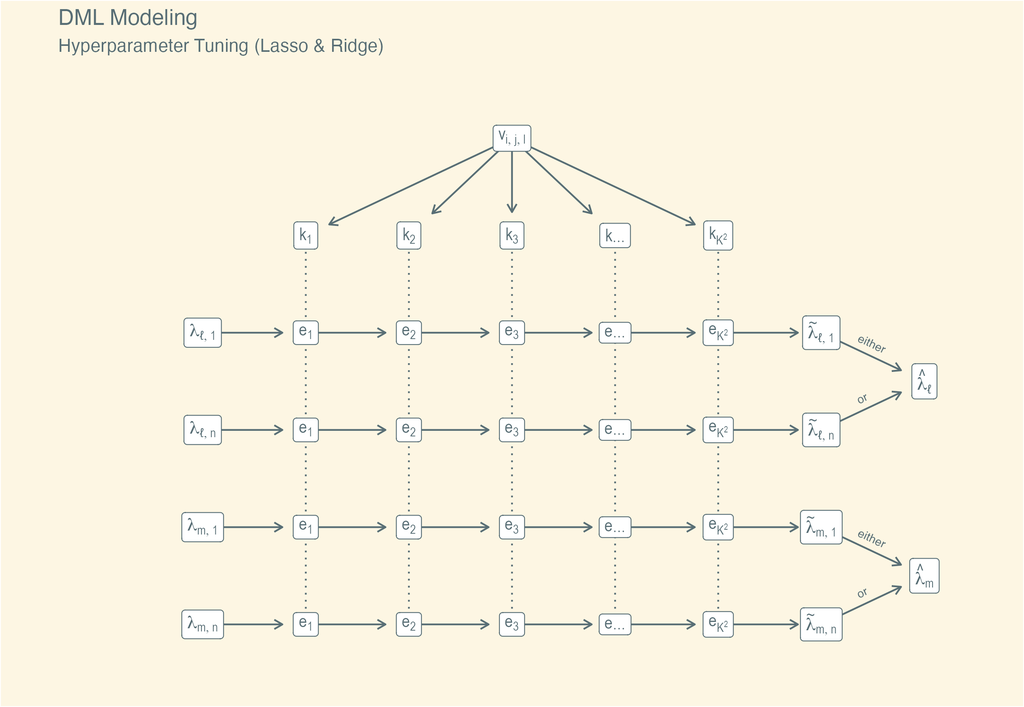

Figure 3: DML Tuning Flowchart (Regularized-Regression Learners & Two-Way Cluster-Robust Resampling). Note that each $e_{i}$ represents an evaluation moment, wherein the candidate $\lambda$ fit on $([N] \backslash I_{k}) \times ([M] \backslash J_{\ell})$ is appraised with $I_{k} \times J_{\ell}$; $\tilde{\lambda}$ the aggregated performance score for the candidate (e.g., mean MSE); and $\hat{\lambda}$ the selected candidate.

In most instances, I tune hewing to or starting from `DoubleML` and `mlr3`’s default settings and recommendations. The reason I do so is twofold: to promote model simplicity and to safeguard against selecting the worst-performing specifications.[^119] First, as indicated above, I cross-validate using folds split from the full sample (i.e., $\mathbf{v}_{i,j,l}$), which is in keeping with the `DoubleML` default.[^120] Though users may optionally cross-validate on each fold drawn for the final DML fits (see Section 2.3.5.3), I refrain from doing so because it is $K$- or $K^{2}$-times more costly and known to perform similarly to full-sample cross-validation in any case.[^121]

<sup>119</sup> To clarify my logic on the latter point, if default settings are “good enough” for most applications, then they are highly-likely to outperform at least some alternative settings. Hence, the defaults should be regarded as minimally safe, insofar as one can reasonably expect them to not be worst-performing settings.

<sup>120</sup> For more on this default—as well as its alternative—see the [`DoubleML` User Guide](https://docs.doubleml.org/stable/guide/learners.html) section on hyperparameter tuning.

<sup>121</sup> To be precise, the cost of on-fold tuning is $K_{DML}*K_{CV}$ or $K^{2}_{DML}*K^{2}_{CV}$: the number of folds selected for DML cross-fitting times the number of desired cross-validation folds. The similar performance of full-sample and on-fold cross-validated tuning is proven in Bach et al. (2024b, pp. 8-9).

<sup>122</sup> Note that users wishing to tune `lambda` must do so through the $s$ parameter. For an explanation, see `mlr3`’s documentation on the [`glmnet` regression learner](https://mlr3learners.mlr-org.com/reference/mlr_learners_regr.glmnet.html).

Next, I begin to define the tuning grid, specifying the hyperparameters and spaces thereof. For the regularized-regression models, defined by hyperparameters $\lambda$ and $\alpha$, I exclusively tune $\lambda$, since lasso and ridge require $\alpha = 1$ and $\alpha = 0$, respectively. To do so, I set $\alpha$ properly and specify the space from which the $\lambda$ values will be sampled—namely, the range `mlr3` recommends for models using `glmnet`, the main dependency supporting regularized-regression tasks in the `mlr3` ecosystem.[^122] For the tree-based models, I tune:

- Random forests
  1. `mtry.ratio`
  2. `replace`
  3. `sample.fraction`
- Boosted trees
  1. `eta`
  2. `nrounds`
  3. `max_depth`
  4. `colsample_bytree`
  5. `lambda`
  6. `subsample`
  7. `min_child_weight`

These mostly correspond to the `mlr3`-recommended tuning hyperparameters for tasks using `ranger` (random forests) and `xgboost` (boosted trees). For random forests, although `num.trees` is among the four hyperparameters recommended to tune, I set it at $500$ throughout to limit runtimes, and because increasing it did not yield noticeable performance gains. Likewise, `alpha` and `colsample_bylevel` are tuning-recommended for boosted trees, though I set them both to $1$ in the interest of simplification and since changes thereto did not meaningfully affect performance. The tuning space of each remaining hyperparameter either follows the `mlr3` recommendation or narrows it based on preliminary testing pointing to better or more-efficient performance along a truncated portion of the original range.[^123]

<sup>123</sup> Note that `min_child_weight`, for boosted trees, is not among the Bischl et al. (2023) recommendations, though `mlr3` does provide ranges for it on account of other authors’ advice. Ultimately, I tune the hyperparameter because doing so seems to improve performance. For all recommended tuning hyperparameters and spaces, see the [`mlr3tuningspaces` defaults](https://mlr3tuningspaces.mlr-org.com/reference/mlr_tuning_spaces_default.html). For the tuning ranges I ultimately specify for each task, please refer to my code (accessible in my dissertation’s [Github repository](https://github.com/bkey15/dissertation)).

<sup>124</sup> To illustrate, take the elastic-net case, which tunes two hyperparameters, $\lambda$ and $\alpha$. Setting $N = 10$ will result in a $10^{2}$-row grid containing all combinations of the sampled $\lambda$ and $\alpha$ values.

Afterwards, I finalize the tuning grid by fixing its search strategy and resolution. For the regularized-regression learners, I employ a “grid” search, which finds $N$ equally-spaced points between and inclusive of the tuning ranges’ lower and upper bounds. For the tree-based learners, on the other hand, I specify a “random” search, which draws $N$ combinations of values from the pre-defined tuning spaces stochastically. Informing these choices primarily is the consideration of cost. Specifically, although the nonrandom grid search is the ideal, guaranteeing a consistent and predictably-spaced draw of possible values, capturing a representative sample at a relatively-low resolution with it is only feasible when the total number of hyperparameters to tune is small. Indeed, if one’s goal is to evaluate $N$ points along each range, then the grid will grow exponentially for each hyperparameter added thereto.[^124] Since the regularized-regression learners tune a single hyperparameter, $\lambda$, I can comfortably deploy the grid search whenever I use them. By contrast, the tree-based learners tune a greater number of hyperparameters, and their computational expenses are far higher in the first place. To keep costs tolerable for the tree-based models, I resort to random searches, conceding that they may occasionally miss more high-performing combinations. Ultimately, I set resolutions of $N = 10$ and $N = 12$ for the regularized-regression and tree-based grids, respectively, as increases beyond these seemed (in testing) to neither yield meaningful gains to performance nor substantively change my results.

Last, as to the performance metrics, I keep the `mlr3` default of MSE for regression tasks, but I depart from said default for classification tasks, opting for log loss in lieu of classification error. I shall elaborate on this latter choice when I cover Chapter 3 (Section 3.4), as it is the only instance wherein I consider classification tasks. Irrespective of task, however, I aggregate the performance scores as per the `mlr3` default algorithm, which simply averages the scores found from each $k \in [K]$ evaluation on test set $I_{k}$ per $n \in [N]$ candidate.[^125] In the case of the regularized regressions, for example, this results in a mean MSE for each $\lambda$, and that with the lowest mean is chosen for the final DML fits (see Figure 3).[^126]

<sup>125</sup> See the [Measure Class help file](https://mlr3.mlr-org.com/reference/Measure.html) for more on the default score aggregator.

<sup>126</sup> Put differently, with respect to the regularized-regression learners, for each candidate $\lambda$, MSE is computed per $k \in [K]$ evaluation of $I_{k}$. If $K = 10$, there will be ten scores, all of which are averaged to form a mean MSE for the candidate. Each $\lambda$ is then compared by this score, and that with the lowest is selected for the final DML fits.

<sup>127</sup> Sasse et al. (2025) offer a helpful primer on data leakage.

The final major decision I make regarding tuning is to implement grouped resampling. A chief concern of all machine-learning practitioners is “data leakage,” whereby identical information finds its way into both the training and test sets. This leads to overly-optimistic assessments of model performance (i.e., overfitting), resulting in degraded predictions on new, previously-unseen data.[^127] Though splitting the data into test sets $I_{k}$ and training sets $I_{k}^{c}$ generally helps combat leakage, since each $I_{k}$ and $I_{k}^{c}$ pair must be disjoint observation-wise (as we saw in Section 2.3.3), the problem may still rear its head when the data feature natural groupings with unique statistical patterns (e.g., clustering by country and year). For instance, if all $I_{k}$ and $I_{k}^{c}$ contain observations of both countries $i$ and $j$, then the model—whilst evaluating on $I_{k}$—will re-encounter the country-specific patterns it learned training on $I_{k}^{c}$, due to which it will likely generate relatively-accurate predictions and report high performance. However, because the countries appearing in $I_{k}$ and $I_{k}^{c}$ are always identical, the model never considers how it might perform when asked to predict on data for a different country—say $z$. In all likelihood, then, the model is unduly-sanguine about its external validity; and if selected, it will be prone to poor prediction when presented with $z$’s data.

To tackle this source of leakage, practitioners frequently implement “grouped” resampling, which simply executes set-sorting by group rather than by observation. In this way, training fits are evaluated on how well they predict for not only new observations, but also new groups, since it enforces group-wise mutual exclusivity for every $I_{k}$ and $I_{k}^{c}$ pair. Continuing with the previous example, countries $i$ and $j$ would be assigned to one test set each (e.g., $i \in I_{1}$ and $j \in I_{2}$), such that $i$ and $j$ would also complement each other in the accompanying training sets (e.g., $j \in I_{1}^{c}$ and $i \in I_{2}^{c}$). A model trained on these splits may exhibit “worse” performance initially, since the training fits are asked to predict for a different country with (presumably) different data patterns; but with respect to generalizability, its performance is more realistic, meaning it is likely to give better predictions for country $z$ (and others) if selected.[^128]

<sup>128</sup> A useful summary and visualization of grouped resampling can be found in [Applied Machine Learning Using `mlr3` in R](https://mlr3book.mlr-org.com/chapters/chapter3/evaluation_and_benchmarking.html#grouped-resampling).

<sup>129</sup> As a reminder, for finite samples, optimizing out-of-sample performance enhances the reliability of $\hat{\theta}_{0}$ and inference about it, since doing so shrinks $\parallel \hat{\eta}_{0} - \eta_{0} \parallel_{L^{2}}$ and thus the maximum bias of the learner producing $\hat{\theta}_{0}$.

<sup>130</sup> Future years and spatial units (i.e., countries) constitute another source of categorical variance, though they prove less problematic: valid inference may still be achieved for the time periods and political geographies defined for each $\mathbf{v}_{i,j,l}$.

Although my research agenda is ultimately more interested in inference than it is in predicting on new or future data, *per se*, I still turn to grouped resampling for a few reasons. First, as explained in Section 2.3.4.1, the quality of inference about $\hat{\theta}_{0}$ in the DML paradigm is only as good as the learners generating it are out-of-sample robust.[^129] Optimizing external validity, then, is indispensable, hence why adopting grouped resampling—a technique that assists in doing so—is unequivocally sensible. Second, my preprocessing decisions imply the possibility of alternative group specifications, rendering robustness thereto an immediate concern. As we saw in Section 2.2.1, I determined cases’ country codes thoughtfully yet discretionally, ineluctably sidestepping other categorical choices. Fortunately, concerns about robustness to these unselected options may be readily allayed through grouped resampling—which, as aforementioned, strengthens robustness to unseen groupings in general—making the procedure all-the-more appropriate.[^130]

Naturally, the primary groupings inhering in panel data $\mathbf{v}_{i,j,l}$ are spatial (country) and temporal (year). `mlr3`—the dependency on which `DoubleML` relies for tuning—cannot prepare training-test set pairs disjoint along two or more dimensions in the manner that `DoubleML` does for two-way cluster-robust cross-fitting (see Section 2.3.5.3.1).[^131] Nonetheless, part of the code I write for my BCR procedure mostly replicates how `DoubleML` resamples in this case,[^132] enabling me to supply `mlr3` with custom splits that respect multiway disjointness. Specifically, then—and having identified country and year as my clusters of interest, as we shall soon see (Section 2.3.5.3.1)—for my BCR models and for each $\mathbf{v}_{i,j,l}$, I form four sets of spatially-buffered and cluster-robust splits, passing the first to `mlr3` for tuning and the remaining three to `DoubleML` for each $r \in [R]$ cross-fitting rounds.

<sup>131</sup> The one-variable restriction for grouped resampling is clearly stated in the reference document for [`mlr3` task class](https://mlr3.mlr-org.com/reference/Task.html).

<sup>132</sup> I qualify that my code “mostly” replicates `DoubleML`’s for resampling in the two-way cluster-robust instance because, in practice, they differ only in the use of spatial buffering (as we shall see in Section 2.3.5.3.2).

##### 2.3.5.3 Final Fits

###### 2.3.5.3.1 Cluster-Robust DML

After optimizing all necessary or recommended hyperparameters, I perform the final fits utilizing cluster-robust DML—an extension of the basic-DML framework outlined in Section 2.3.3—and spatial buffering. In this section, I shall delineate how the former generally functions, since the buffering operation I propose and implement (see Section 2.3.5.3.2) ultimately constitutes a minor intervention thereto. Also, I will give a sedulous explanation for my decision to treat year as a cluster, the problem of serial correlation notwithstanding.

Developed in Chiang et al. (2021) to counter complications arising from grouped data, cluster-robust DML rests on two pillars: grouped/clustered resampling for cross-fitting and cluster-robust standard errors.[^133] The first—similar to that discussed in Section 2.3.5.2—ensures cluster-wise independence for each training- and test-set pair, thereby minimizing data leakage. Importantly, multiple clusters may be rendered disjoint at once, such that in the two-way/$K^{2}$ (e.g., country-year) case, cross-fitting proceeds as follows:[^134]

<sup>133</sup> Note that I use “groups” and “clusters” interchangeably, since both refer to categories (e.g., countries and years) structuring the data and thus threatening not only data leakage, but also invalid standard-error estimation.

<sup>134</sup> My summary is adapted from Chiang et al. (2021, pp. 1050-1051) and the [`DoubleML` User Guide](https://docs.doubleml.org/stable/examples/R_double_ml_multiway_cluster.html).

1. Assume that the data cluster along two dimensions, characterized by $N$ groups in the first and $M$ groups in the second. Accordingly, all observations are double-indexed, such that $\{\mathbf{S}_{ij} : i \in \{1, ..., N\}, j \in \{1, ..., M\}\}$.
2. Randomly partition $[N] := \{1, ..., N\}$ and $[M] := \{1, ..., M\}$ into $K$ user-specified subsets $\{I_{1}, ..., I_{K}\}$ and $\{J_{1}, ..., J_{K}\}$.
3. Take the Cartesian product of these, giving $[K]^{2} := \{I_{1}, ..., I_{K}\} \times \{J_{1}, ..., J_{K}\}$ subsets.
4. For each $(k, \ell) \in [K]^{2}$, estimate $\eta_{0}$ using all $(i, j)$ observations in $([N] \backslash I_{k}) \times ([M] \backslash J_{\ell})$. That is:

$$\hat{\eta}_{0, k\ell} = \hat{\eta}_{0}\left((\mathbf{S}_{ij})_{(i,j) \in ([N] \backslash I_{k}) \times ([M] \backslash J_{\ell})}\right)$$

5. Solve for causal estimate $\hat{\theta}_{0}$. Following the software-default algorithm given in Section 2.3.3 (i.e., DML2):[^135]

<sup>135</sup> Here, $|I_{k}|$ and $|J_{\ell}|$ signify the cardinality of sets $I_{k}$ and $J_{\ell}$—that is, the number of groups belonging to each respective subset.

$$\begin{align*}
\frac{1}{K^{2}} \sum_{k = 1}^{K} \sum_{\ell = 1}^{K} \frac{1}{|I_{k}||J_{\ell}|} \sum_{(i, j) \in I_{k} \times J_{\ell}} \psi(\mathbf{S}_{ij}; \hat{\theta}_{0}, \hat{\eta}_{0,kl}) = 0
\end{align*}$$

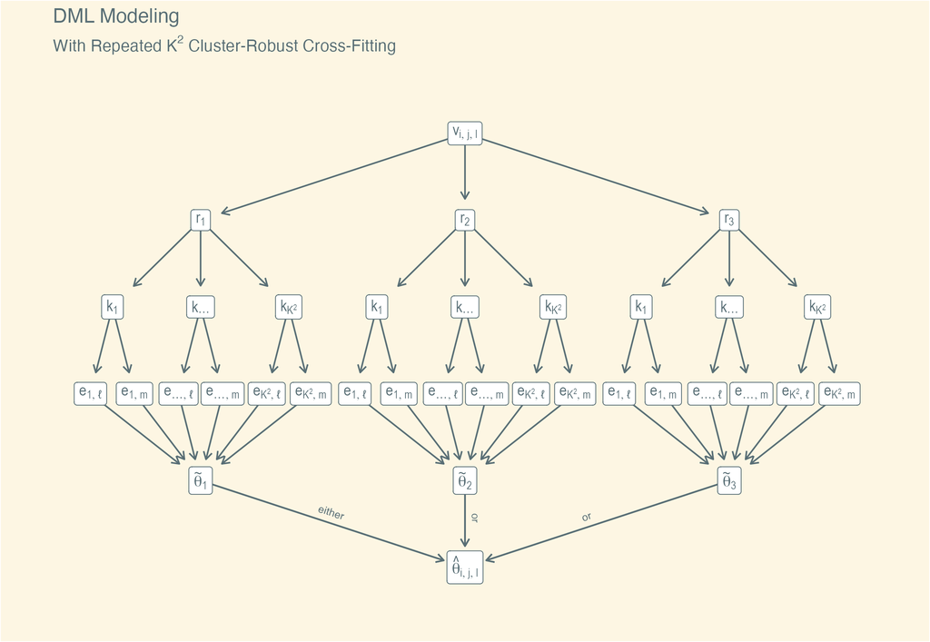

Figure 4: DML Flowchart. Cross-fitting proceeds as follows: (1.) The first round ($r_{1}$) is initialized. (2.) The dataset is split into $K^{2}$ folds as per two-way cluster-robust DML. (3.) Evaluation moments ($e_{i}$) occur for each nuisance part $\ell$ and $m$, namely whereby the model is trained on the folds disjoint from $k$ and subsequently tested on $k$. Residuals from these evaluations are recorded and concatenated. (4.) Residualized $Y$ (found estimating $\ell$) is regressed on residualized $D$ (found estimating $m$), yielding provisional causal estimate $\tilde{\theta}_{1}$. (5.) Steps 2-4 are repeated $R$ times. (6.) The median $\tilde{\theta}_{i}$ is selected as the final estimate, $\hat{\theta}_{i,j,l}$. Note that short-stacking, as described in Section 2.3.5.4, occurs between steps (3.) and (4.), transforming the concatenated residuals prior to finding each $\tilde{\theta}_{i}$.

The second cornerstone—cluster-robust standard errors—adapts a practice commonplace in models relying on grouped data. Within-cluster correlation of errors jeopardizes valid inference by underestimating true standard errors, resulting in erroneous rejections of null hypotheses (i.e., Type 1 errors).[^136] To mitigate the threat posed by this type of correlation, researchers typically opt for standard-error estimators whose formulae are designed to control for it (and are therefore “cluster-robust”). For cluster-robust DML, Chiang et al. (2021) propose estimating variance by:

<sup>136</sup> Examples of within-cluster error correlation, and the consequences thereof, are summarized well in Cameron et al. (2011, pp. 238-239) and Cameron & Miller (2015, p. 318).

$$\begin{align*}
\hat{\sigma}^{2}
=
\hat{J}^{-1}
\hat{\Gamma}
\hat{J}^{-1}
\end{align*}$$

In the $K^{2}$ case, $\hat{\Gamma}$ and $\hat{J}$ are themselves found by:[^137]

<sup>137</sup> Note that the below formulae use the notation $n \wedge m := \text{min}\{n,m\}$.

$$\begin{align}
\hat{\Gamma}
=
\frac{1}{K^{2}}
\sum_{(k,l)\in[K]^{2}}
\Bigg[
\frac{|I_k|\wedge|J_\ell|}
{|I_k||J_\ell|}
\Bigg(
&
\sum_{i\in I_k}
\sum_{j\in J_\ell}
\sum_{j'\in J_\ell}
\psi(\mathbf S_{ij};\hat\theta,\hat\eta_{kl})
\psi(\mathbf S_{ij'};\hat\theta_{0},\hat\eta_{kl})
\\
&+
\sum_{i\in I_k}
\sum_{i'\in I_k}
\sum_{j\in J_\ell}
\psi(\mathbf S_{ij};\hat\theta,\hat\eta_{kl})
\psi(\mathbf S_{i'j};\hat\theta_{0},\hat\eta_{kl})
\Bigg)
\Bigg]
\end{align}$$

$$\begin{align*}
\hat{J}
=
\frac{1}{K^{2}}
\sum_{(k,l)\in[K]^{2}}
\frac{1}{|I_{k}||J_{\ell}|}
\sum_{i \in I_{k}}
\sum_{j \in J_{\ell}}
\psi_{a}(\mathbf S_{ij};\hat\theta,\hat\eta_{kl})
\end{align*}$$

Letting $\underline{C} := N \wedge M$, the cluster-robust standard error may then be estimated simply by:

$$\begin{align*}
SE = \sqrt{\hat{\sigma}^{2}/\underline{C}}
\end{align*}$$

With $SE$, a $(1 - \alpha)$ confidence interval may also be reported by:

$$\begin{align*}
\left[
\hat{\theta}
\pm
\Phi^{-1}
(1 - \alpha/2)
\sqrt{\hat{\sigma}^{2}/\underline{C}}
\right]
\end{align*}$$

As emphasized in Section 2.3.5.2, my data manifestly exhibit grouping (i.e., by geography and time), the deleterious impact thereof on inference is imperative to alleviate. Moreover, Cameron et al. (2011, p. 238) emphasize that—for panel data—clustered errors may persist notwithstanding controls for unit and temporal effects, rendering such solutions insufficient. Therefore, in my estimation, it is both reasonable and necessary for me to consider cluster-robust DML.

Controlling for clustering by country is perhaps the simplest to defend: absent evidence to the contrary, I presuppose that my panel data are typical in exhibiting within-country correlation of errors, an archetypal example of clustering,[^138] such that it is logical to formally identify country as a cluster influencing the DML implementation. The matter of clustering in the temporal dimension, on the other hand, merits greater deliberation in view of the unique complications time poses. Specifically, panel data are also known to exhibit serial correlation: observations at time $t \in [T] = \{1, ..., T\}$ may be dependent on those at nearby time points (e.g., $t-1$ or $t+1$), generally due to the behavior of historical trends, which may persist, transform gradually, or change course abruptly following a unit-specific or systemic “shock.” Hence, partitioning the data simply by $t$—to wit, treating time as a cluster akin to unit—cannot overcome serial correlation: for example, if unit-year observations $i_{t}$ and $i_{t-1}$ are assigned to the test and training sets, respectively, then these sets are not perfectly disjoint if $i_{t}$ and $i_{t-1}$ are indeed serially correlated.

<sup>138</sup> Cameron et al. (2011, pp. 239 & 246-247), for instance, cite clustering by country as a motivating case for their multiway procedure.

<sup>139</sup> For example, let $T = 4$ and $K = 2$. Then, $K_{1} = \{t_{1}, t_{2}\}$ and $K^{c}_{1} = \{t_{3}, t_{4}\}$. Also, $K_{2} = \{t_{3}, t_{4}\}$ and $K^{c}_{2} = \{t_{1}, t_{2}\}$.

<sup>140</sup> For example, let $T = 4$ and $K = 2$. Then, $K_{1} = \{t_{1}, t_{2}\}$ and $K^{c}_{1} = \{t_{4}\}$. Also, $K_{2} = \{t_{3}, t_{4}\}$ and $K^{c}_{2} = \{t_{1}\}$ In effect, then, neighbors-left-out resampling is a temporal analogue of the BCR procedure I shall soon introduce.

Unfortunately, a standard, “best-practice” solution for serial correlation in DML applications has yet to be developed, as Fuhr & Papies (2024) underline most comprehensively. In the static-panel case, Clarke & Polselli (2025) recommend resampling by unit and thus each unit’s time series; however, residual temporal dependence may remain, since observations at and near $t$ are eligible for assignment to both the training and test sets simultaneously (Fuhr & Papies, 2024, p. 11). Furthermore, practitioners may resample by time directly using one of three strategies. The first is the aforementioned $t$-wise split rule, which randomly partitions the data by period into $K$ folds. Put differently, time is treated as a cluster and resampled accordingly, effectively ignoring the problem of serial correlation. The second, by contrast, is nonrandom, ordering the time dimension chronologically and dividing it into $K$ adjacent folds.[^139] The third employs a “neighbors-left-out” (NLO) procedure proffered by Semenova et al. (2023), which forms $K$ adjacent folds similarly, but subsequently drops immediately-adjacent periods from the corresponding training sets.[^140] Although the second and third options clearly do more to limit the number and proximity of adjacency points, thereby promising to reduce serial correlation the most (Fuhr & Papies, 2024, p. 15), it is not immediately clear how these resampling methods ought to be reconciled with cluster-robust DML in the event doing so is desired. Namely, if the splitting procedures thereof presume the existence of multi-period “eras” characterized by within-era dependence yet between-era independence, as appears to be the case, then is it more theoretically justified to interpret era or period as the temporal cluster of interest? The answer to this question is undoubtedly of some moment: favoring the former will generally lower $\underline{C}$ and thereby inflate the $SE$ estimate, perhaps incorrectly so, since the number of $K$ folds will typically be lower than those of both the $T$ periods and the units (e.g., $C$ countries).

Ultimately, I elect to treat time as an ordinary cluster, adopting the $t$-wise split rule and effectively proceeding with two-way ($K^{2}$) cluster-robust DML. Years—my periods of interest—may be serially correlated, but so too do they cover historical “shocks”, whose effects may be felt acutely yet briefly (e.g., over a single year or short span of years). A central motivation for the original multiway clustering literature, in fact, was the observed “factor structure” imposed on years in panel data by such shocks (Cameron et al., 2011, pp. 238-239).[^141] Treating country and year as similarly-structured clusters, then, is not only theoretically defensible, but also with clear precedent. Moreover, as aforementioned, simple-chronological and NLO splitting procedures may imply that the temporal cluster of interest is not year but era. If so, they require the user to adopt a fundamentally-different assumption about the cluster’s structure—a pivot that may be not only unintended, but also arbitrary. Indeed, the validity of dividing time into $K$ disjoint and equally-long eras, beginning and concluding at the sample’s start and end years, may be unknown, such that any selection of $K$ may be hard to defend theoretically. Obviating the need to confront this complication, on the other hand, is the choice to simply cluster by year.

<sup>141</sup> To clarify, shocks may prompt years to take on a factor structure by introducing a shared, unobserved component to units’ error terms at year $t$, with similar or different effects across units.

<sup>142</sup> The specific DGP used in this simulation is their most “complex” (Fuhr & Papies, 2024, p. 19), for it assumes a high-degree of serial correlation and that time-invariant (i.e., unit-specific) unobserved heterogeneity influences the treatment, outcome, and confounders each. For more, see Fuhr & Papies (2024, p. 13 & pp. 19-21).

To be sure, I do not claim that my recognition of annual clustering resolves the problem of serial correlation. On the contrary, I tolerate it: adjacent years are allowed to compose either side of any training-test set pair. Nevertheless, I already attend to shocks due to their potential influence on the treatment effect as “triggers” (or confounders), as we shall later see (in Section 3.1.1), and I anticipate that care for their impact on the error term will be equally warranted given their possible role in inducing within-period correlation of errors. Therefore, it is fair to characterize shocks as a principal, overarching concerns for my modeling. Faced with a tradeoff between handling serial correlation and doing so for shock-induced temporal clustering, I ultimately favor the latter: on balance—and in my setting—shocks appear more theoretically salient, and as aforementioned, imply the more defensible period-wise (vis-à-vis era-wise) temporal dependence structure. Initial encouragement for my decision to cluster by year may be found in Fuhr & Papies (2024), whose cross-fitting simulation finds that resampling by period yields estimation errors “hardly distinguishable” from those of simple-chronological and NLO partitioning (pp. 20-21), signalling that period clustering is minimally safe.[^142]

###### 2.3.5.3.2 Buffered Cluster-Robust (BCR) DML

Having settled my approach towards the temporal dimension, I turn my attention to space. As a review, the spatial dimension—like that of time—may encompass observations correlated through proximity. To control for such dependencies, I have elected to implement the SLX model, which—generally speaking—averages the variables of any given unit’s neighbors, following a membership rule supplied by the user, and including these “lags” as covariates (see Section 2.2.3). Moreover, I have specified country, representing the spatial units of interest, as one of two clusters upon which my datasets $\mathbf{v}_{i,j,l}$ will be partitioned. Nonetheless, resampling by unit alone will not ensure disjoint training-test set pairs when spatial lags are present: lags in one set may be formed from observations assigned to the other. To illustrate with a simple yet particularly-severe example, consider countries $i$ and $j$, who are each other’s only neighbors. Then, when either $i$ or $j$ is assigned to the test set, $i$ or $j$’s data will be almost entirely replicated in the training set as its neighbor’s spatial lags.

To prevent lag-induced data leakage, promoting compatibility between SLX and cluster-robust DML, I propose introducing spatial buffering to the resampling step, forming a general procedure I denominate *buffered cluster-robust DML (BCR-DML)*. In simple terms, spatially-buffered resampling randomly partitions units into $K$ test folds, as is typical, but then constructs the training folds by assembling all complimentary units not falling under the user’s spatial exclusion rule (e.g., contiguity or distance). Essentially, then, training-test set pairs are marked by “buffers” separating proximate units. Defined exclusively by its adoption of this resampling scheme, BCR-DML constitutes a minimally-invasive intervention to ordinary cluster-robust DML; indeed, spatial buffering simply optimizes disjoint resampling in the SLX setting, such that no fundamental adjustments to the underlying assumptions or mathematical operations of the regular procedure need occur.

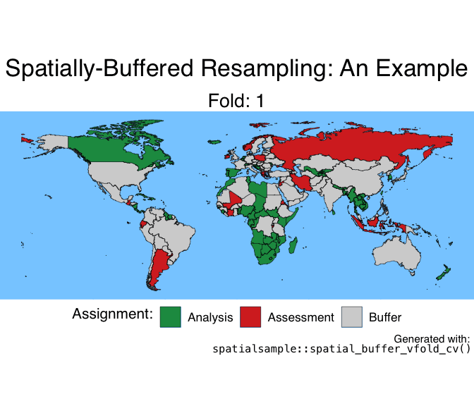

Figure 5: An illustration of spatially-buffered resampling, taken from the very first country-splits drawn in Chapter 1. Note that the polygons appearing on the map are only those countries comprising the Chapter 1 data.

Formally, BCR-DML proposes a variation on the first few steps of the cluster-robust DML procedure enumerated in Section 2.3.5.3.1. Namely, in the two-way cluster case, featuring one spatial cluster:

1. Assume that the data cluster along two dimensions, one of which is spatial, such that there are $N$ spatial groups and $M$ other groups. In this setting, all observations are double-indexed, such that $\{\mathbf{S}_{ij} : i \in \{1, ..., N\}, j \in \{1, ..., M\}\}$.
2. Randomly partition $[N] := \{1, ..., N\}$ and $[M] := \{1, ..., M\}$ into $K$ user-specified subsets $\{I_{1}, ..., I_{K}\}$ and $\{J_{1}, ..., J_{K}\}$.
3. Take the Cartesian product of these, giving $[K]^{2} := \{I_{1}, ..., I_{K}\} \times \{J_{1}, ..., J_{K}\}$ subsets.
4. Let $b$ be a user-specified spatial exclusion rule. For each $i \in I_{k}$, apply $b$ thereto, identifying any $i' \in [N]$ observation satisfying it. In effect, we now have buffer-aware subsets $\{I^{b}_{1}, ..., I^{b}_{K}\}$, wherein each $I^{b}_{k}$ includes not only all $i \in I_{k}$, but also all $i' \in [N]$ satisfying $b$.[^143]
5. For each $(k, \ell) \in [K]^{2}$, estimate $\eta_{0}$ using all $(i, j)$ observations in $([N] \backslash I^{b}_{k}) \times ([M] \backslash J_{\ell})$. That is:

<sup>143</sup> The resampling software may or may not literally form $\{I^{b}_{1}, ..., I^{b}_{K}\}$ (e.g., for any $I_{k}$, it could instead drop from the compliment $I^{c}_{k}$ any $i' \in [N]$ satisfying $b$ with respect to $i \in I_{k}$). To minimize the formulaic differences between BCR-DML and cluster-robust DML, however, I prefer the $I^{b}_{k}$ notation. My diction in this step thus intends to clarify what $([N] \backslash I^{b}_{k})$ represents: the buffered compliment of $I_{k}$.

$$\hat{\eta}_{0, k\ell} = \hat{\eta}_{0}\left((\mathbf{S}_{ij})_{(i,j) \in ([N] \backslash I^{b}_{k}) \times ([M] \backslash J_{\ell})}\right)$$

Subsequently, cluster-robust DML proceeds as per usual, leveraging $\hat{\eta}_{0, k\ell}$ to find $\hat{\theta}_{0}$ and estimate $SE$.

<sup>145</sup> That is, the neighborhood-membership rule for computing the spatial lags is likewise applied using edge-to-edge (i.e., border-to-border) distance. For more on the edge-to-edge distance guarantee, see the [`spatialsample` article on buffering](https://spatialsample.tidymodels.org/articles/buffering.html).

The BCR-DML procedure I put forward entails two primary drawbacks—one practical, the other theoretical. First, as aforementioned (and as illustrated plainly by Figure 5), spatial buffering excludes from the training set any unit satisfying the exclusion rule ($b$) with respect to the test set. In effect, then, buffering shrinks the pool of units eligible for training-set assignment, forming training sets even smaller than those that would materialize under ordinary cluster-robust DML. Accordingly, BCR-DML only reinforces the need for a relatively-high starting $K$. However, I have identified $K = 10$ as not only low enough to ensure reasonable computational costs (particularly in view of my Quest access), but also high enough to yield large training sets relative to the test sets, buffering notwithstanding. Therefore, in my case, BCR-DML poses few practical hurdles, enabling me to adopt the method comfortably.

Second—and perhaps more seriously—recent literature has pushed back on some of the fundamental assumptions undergirding the cluster-robust DML paradigm. Specifically, for correlated observations—including clustered, spatial, and time-series data—Balkus et al. (2026) posit that valid estimation of $\hat{\theta}_{0}$ may be achieved via basic-DML cross-fitting, whereby sample $\mathbf{S}$ is treated “as-IID” for training-test set splitting (see Section 2.3.3). Their reasoning is that the procedure inherently (and asymptotically) eliminates the empirical process term of the nuisance estimator’s bias, irrespective of whether observations are correlated. Consequently, “bespoke” resampling methods purposing to mitigate training-test set correlation (e.g., cluster-robust or BCR resampling) are to be regarded as unnecessary for cross-fitting.[^146]

<sup>146</sup> A brief articulation of their argument may be found in Balkus et al. (2026, pp. 1-3).

<sup>147</sup> These assumptions specifically extend the Central Limit Theorem (CLT) for dependent data and nuisance-estimator convergence rate to network/spatial data, imposing additional requirements. For more, see Balkus et al. (2026, pp. 11-12).

##### 2.3.5.4 Stacking

Ultimately, I carry out the BCR-DML procedure using each of the four “base” or candidate learners introduced in Section 2.3.4: lasso, ridge, random forests, and boosted trees. Recall that I presented two general options for proceeding with inference based on these learners’ results: selecting the learner with the best out-of-sample performance (e.g., overall or per nuisance part), or aggregating the residuals through an ensemble mechanism such as stacking. Presently, the DML literature does not agree on a preferred learner-selection strategy. Bach et al. (2024b), for example, compare three strategies. The first selects on “combined nuisance loss,” an overall-performance metric of the form, in PLR:

$$RMSE(\hat{m}_{0})*\left(RMSE(\hat{m}_{0}) + RMSE(\hat{\ell}_{0})\right)$$

The second selects on predictive performance for $Y$, and the third executes stacking. Through their simulations, the authors find that selecting on combined loss yields the lowest predictive error, motivating their endorsement of it; however, they acknowledge that the three methods compare favorably to each other, and stacking is shown to exhibit the smallest dispersion in bias.[^148] By contrast, in their own simulations and applied study, Ahrens et al. (2025b) compare approaches that select the “single-best” performing learner per nuisance part against three different stacking methods. They observe that single-best selection performs similarly to stacking when there indeed exists a clear best learner, but that it otherwise delivers more erratic causal estimates. As such, they advocate for stacking as a safer default.[^149]

<sup>148</sup> Predictive error is assessed specifically on mean and median relative RMSE (rRMSE). For a discussion of their exact findings and the formulae for both combined loss and rRMSE, see Bach et al. (2024b, pp. 7, 10-11, & 18).

<sup>149</sup> For more on their central findings and recommendations, see Ahrens et al. (2025b, pp. 258 & 265-266).

<sup>150</sup> To be precise, there are—in effect—two terms that constitute combined loss: the square of $RMSE(\hat{m}_{0})$ (i.e., $MSE(\hat{m}_{0})$) and $RMSE(\hat{\ell}_{0})$ as indexed by $RMSE(\hat{m}_{0})$. $\hat{m}_{0}$ contributes to both of these, and in one is accorded exponential influence. $\hat{\ell}_{0}$, meanwhile, contributes to just one of the terms. Therefore, it is axiomatic that combined loss treats the performance of the treatment estimator, $\hat{m}_{0}$, as as a more important indicator of overall performance.

<sup>151</sup> I have saved the MSEs and stacking weights for each learner, results I am happy to provide upon request.

These perspectives being taken into account, I elect to proceed with stacking—an operation that, in sum, combines the results of base learners through optimized weights, thereby constructing a “super learner” whose predictive performance on the sample is guaranteed to be no worse than that of the best-performing base learner. First, as aforementioned (see Section 2.3.4.2.1), the true DGPs for my samples are unknown, rendering the discovery of true best learners unlikely, perhaps even impossible. In this setting, stacking offers a safer path forward; and indeed, even if such a learner were to exist, as Ahrens et al. (2025b) note, stacking would simply approximate single-best selection by assigning said learner a disproportionately-larger weight (p. 258). Second, the formula for combined loss prioritizes performance for the nuisance part estimating the treatment ($\hat{m}_{0}$).[^150] Consequently, those learners better-executing this particular task will tend to be selected under a combined-loss criterion, despite that other learners may perform markedly and systematically better at estimating the outcome ($\hat{\ell}_{0}$). If so, whether combined loss veritably facilitates selection of the overall-best learner would be both theoretically and empirically uncertain. Since my results indeed exhibit such disparities, with tree-based learners generally better at $\hat{\ell}_{0}$ and regularized-regression learners at $\hat{m}_{0}$,[^151] I am further motivated to adopt stacking, a technique endowed with the flexibility to exploit each learner’s complementary strengths.

Following Ahrens et al. (2025b), I employ short-stacking as my preferred stacking method. As with many stacking algorithms, short-stacking solves a constrained least squares (CLS) problem that finds a convex combination of non-negative weights summing to one. Specifically, for basic DML:

$$\begin{align*}
\min_{w_{1}, ..., w_{A}}
\sum_{i = 1}^{n}
\Bigg(
Y_{i} -
\sum_{a = 1}^{A}
w_{a}
\hat{\ell}_{I_{k(i)}^{c}}^{(a)}
(\mathbf{X}_{i})
\Bigg)^{2}
\\
\text{s.t.}
\;
w_{a}
\geq
0,
\sum_{a = 1}^{A}
|w_{a}|
=
1
\end{align*}$$

Here, $w_{1}, ..., w_{A}$ are the stacking weights for each $a \in [A] = \{1, ..., A\}$ base learner and $\hat{\ell}_{I_{k(i)}^{c}}^{(a)} (\mathbf{X}_{i})$ the prediction for test-fold observation $i$ using training data $I_{k(i)}^{c}$ (i.e., all folds wherein the $i$th observation is absent). This problem is solved for all nuisance parts, such that in the PLR case, a combination of $A$ weights is found for $\hat{\ell}_{0}$ and $\hat{m}_{0}$ each.[^152] Of course, the short-stacking algorithm is readily adaptable to BCR-DML, since it need only consider predictions for any $(i, j)$ observation made from buffer-aware training data $([N] \backslash I^{b}_{k(i)}) \times ([M] \backslash J_{\ell(j)})$ (see Section 2.3.5.3.2).

<sup>152</sup> Note that I have $A$ signify the total number of base learners in lieu of $J$, Ahrens et al.’s (2025b) preferred notation, so as to avoid confusion with my other uses of $J$. For more on the notation and intention of CLS stacking algorithms, including short-stacking, see Ahrens et al. (2025b, pp. 252-254).

<sup>153</sup> That the number of candidate learners ($A$) should be small vis-à-vis the sample size ($N$) is the only stipulation for this recommendation. Doubtless, it ought to be satisfied in the vast majority of applied settings, including mine (wherein $A = 4$). For more on this condition, see Ahrens et al. (2025b, p. 254).

<sup>154</sup> For instance, for two-way cluster-robust DML, if $V = 10$ since $K = 10$, then $V^{2} = 100$, meaning conventional and pooled stacking will basically be $100$-times costlier than short-stacking.

<sup>155</sup> For a comprehensive discussion of the alternative stacking algorithms, as well as formulae and visualizations thereof, see Ahrens et al. (2025b, pp. 252-254).

Ahrens et al. (2025b) endorse short-stacking over the alternative stacking procedures since it performs competitively at a steep computational discount.[^153] Essentially, short-stacking computes weight combinations directly from the cross-fitted residuals. Heuristically, then, expenses are proportional to $K \times A$ (or $K^{2} \times A$ for two-way cluster-robust DML), the number of cross-fitting folds multiplied by the number of base learners. By contrast, consider conventional and pooled stacking, the chief alternatives to short-stacking. The conventional algorithm cross-validates $V$ times within each cross-fitting training set, generating residuals from which a unique weight combination per $k$th test fold may be derived. Similarly, pooled stacking performs within-training-set cross-validation $V$ times but instead assembles the residuals into a “pooled” dataset, facilitating the computation of a single weight combination. In either case, expenses are heuristically proportional to $K \times V \times A$, which in practice may be far greater than $K \times A$.[^154] Moreover, stacking incorporating a cross-validation layer as such complicates cluster-robust and BCR-DML, since cluster- and buffer-wise disjoint folds must formed $K$ more times (i.e., for each training set). Finally, in their simulation, Ahrens et al. (2025b) find that short-stacking performs similar to or better than conventional and pooled stacking, its structurally-lower costs notwithstanding.[^155] The advantages short-stacking enjoys are thus decisive, furnishing me with ample reason to adopt it.

To carry out short-stacking, I borrow source code from [`ddml`](https://thomaswiemann.com/ddml/index.html), a package intended to complement `DoubleML` by enabling short-stacking as proposed by Ahrens et al. (2025b).[^156] In sum, for any sample $\mathbf{v}_{i,j,l}$, I first perform BCR tuning and cross-fitting for all $A$ learners using `DoubleML`. Doing so allows me to construct $\mathbf{\hat{Q}} \in \mathbb{R}^{N \times R \times p_{1} \times A}$ and $\mathbf{\hat{V}} \in \mathbb{R}^{N \times R \times p_{1} \times A}$, matrices of cross-fitted residuals for nuisance-part estimates $\hat{\ell}_{0}$ and $\hat{m}_{0}$, respectively.[^157] For $\mathbf{\hat{Q}}$ and $\mathbf{\hat{V}}$ each, I then derive optimal weight sets $\mathbf{W}_{\hat{\ell}_{0}} \in \mathbb{R}^{R \times p_{1} \times A}$ and $\mathbf{W}_{\hat{m}_{0}} \in \mathbb{R}^{R \times p_{1} \times A}$ by solving the `ddml` default CLS algorithm, a non-negative least squares problem summing to one, leveraging the package’s source code to do so.[^158] Finally, I solve $\mathbf{W}_{\hat{\ell}_{0}}\mathbf{\hat{Q}}^{T}$ and $\mathbf{W}_{\hat{m}_{0}}\mathbf{\hat{V}}^{T}$, the results of which I sum for every $i$th row, thereby generating matrices of “stacked” residuals $\mathbf{\hat{Q}}_{stack} \in \mathbb{R}^{N \times R \times p_{1}}$ and $\mathbf{\hat{V}}_{stack} \in \mathbb{R}^{N \times R \times p_{1}}$. These are the basic inputs needed to compute estimated effect(s) $\boldsymbol{\hat{\theta}}_{stack} \in \mathbb{R}^{p_{1}}$ and the accompanying $\mathbf{SE} \in \mathbb{R}^{p_{1}}$, completing the BCR-DML procedure. To perform this final task, I simply borrow the [`DoubleML` source code](https://rdrr.io/cran/DoubleML/src/R/double_ml.R) for cluster-robust DML, deploying $\mathbf{\hat{Q}}_{stack}$, $\mathbf{\hat{V}}_{stack}$, and any other requisite information (e.g., the fold assignments for both observations and clusters).[^159]

<sup>156</sup> `DoubleML` offers far more features, such as specifying custom sample splits and conducting cluster-robust inference, and is embedded in the highly-flexible `mlr3` ecosystem, hence why I use it (and its source code) for all DML operations apart from finding the stacking weights. See the [`ddml` webpage](https://thomaswiemann.com/ddml/index.html) for more on this package’s general capabilities and purpose as a complement to `DoubleML`.

<sup>157</sup> Recall that $R$ denotes the number of cross-fitting rounds and $p_{1}$ the number of treatments. This notation—as well as that for the residuals—first appears in Section 2.3.3.

<sup>158</sup> The default algorithm is denoted by `nnls1`. For the exact source code I implement, see the [`ddml` Github repository](https://raw.githubusercontent.com/thomaswiemann/ddml/master/R/ensemble.R).

<sup>159</sup> I have verified that my borrowing of source code replicates whatever would be produced by the packages automatically, and that $\mathbf{\hat{Q}}_{stack}$ and $\mathbf{\hat{V}}_{stack}$ indeed give lower $MSE$s relative to $\mathbf{\hat{Q}}$ and $\mathbf{\hat{V}}$. I am happy to provide the scripts for and results of these “sanity checks” upon request.

<sup>160</sup> As a reminder, I justify my selection of $K$ and $R$ in Section 2.3.3.

Ultimately, having chosen $K^{2}$ cluster-robust DML and $K = 10$, $K^{2} = 100$; and because $R = 3$, there are then $600$ cross-fits for any given $\hat{\theta}_{i,j,l}$: $100$ per nuisance part—namely, $\hat{m}_{0}$ and $\hat{\ell}_{0}$—per $r \in [R]$ round.[^160]

### 2.4 Pooling

The final step of my methodology rounds off the multiple imputation procedure initiated during preprocessing. As discussed in Section 2.2.2, pooling entails combining the causal statistics found from multiply-imputed datasets $(\mathbf{m}_{i})_{i=1}^{m}$ and performing inference therefrom. Following the procedure set forth in Rubin (1987, pp. 76-77), the `mice` package pools by:[^161]

<sup>161</sup> The following summary adapts those found in [Heymans & Eekhout (2019)](https://bookdown.org/mwheymans/bookmi/rubins-rules.html#significance-testing) and [Van Buren (2018)](https://stefvanbuuren.name/fimd/sec-whyandwhen.html).

1. Taking the mean of estimated effects $(\hat{\theta}_{i})_{i = 1}^{m}$. Namely:

$$\begin{align*}
\bar{\theta}
=
\frac{1}{m}
\sum_{i = 1}^{m}
\hat{\theta}_{i}
\end{align*}$$

2. Letting $(U_{i})_{i = 1}^{m} = (SE_{i}^{2})_{i = 1}^{m}$, finding the within-imputation variance:

$$\begin{align*}
\bar{U}
=
\frac{1}{m}
\sum_{i = 1}^{m}
U_{i}
\end{align*}$$

3. Finding the between-imputation variance:

$$\begin{align*}
B
=
\frac{1}{m - 1}
\sum_{i = 1}^{m}
(\hat{\theta}_{i} - \bar{\theta})^{2}
\end{align*}$$

4. Computing the total variance:

$$\begin{align*}
T
=
\bar{U}
+
(1 + \frac{1}{m})
B
\end{align*}$$

5. With pooled estimate $\bar{\theta}$ and standard error $\sqrt{T}$—and for the null hypothesis $H_{0}: \theta = 0$—computing the $t$-statistic:[^162]

<sup>162</sup> The formula below assumes the use of a two-tailed test, in which case the sign of the $t$-statistic is irrelevant. In [Van Buuren (2018)](https://stefvanbuuren.name/fimd/sec-inference.html), the formula is given by: $t = \frac{\theta - \bar{\theta}}{\sqrt{T}}$.

$$\begin{align*}
t = \frac{\bar{\theta}}{\sqrt{T}}
\end{align*}$$

6. With $df$ degrees of freedom, constructing a confidence interval:

$$\begin{align*}
\bar{\theta}
\pm
t_{1-\alpha/2, df}
\sqrt{T}
\end{align*}$$

In modern implementations, $df$ is found as per the “Barnard-Rubin adjustment”:

$$\begin{align*}
df
=
\frac{df_{old} * df_{obs}}{df_{old} + df_{obs}}
\end{align*}$$

Here, $df_{old}$ refers to Rubin’s original degrees-of-freedom formula and $df_{obs}$ to the estimated observed-data degrees of freedom. Specifically, where $\lambda = \frac{B + B/m}{T}$ and $df_{com}$ is the difference between the $n$ sample size and $k$ number of parameters (i.e., $df_{com} = n - k$):[^163]

<sup>163</sup> [Van Buuren (2018)](https://stefvanbuuren.name/fimd/sec-whyandwhen.html#sec:varianceratios) remarks that $\lambda$ “can be interpreted as the proportion of the variation attributable to the missing data.”

$$\begin{align*}
df_{old}
=
\frac{m - 1}{\lambda^{2}}
\\
df_{obs}
=
\frac{df_{com} + 1}{df_{com} + 3}
df_{com}
(1 - \lambda)
\end{align*}$$

However, because I set $df_{com} = \infty$ (see Section 2.2.5), my formula for $df$ simply reduces to that of $df_{old}$.[^164]

<sup>164</sup> For more on the implication of setting $df_{com} = \infty$, see [Van Buuren (2018)](https://stefvanbuuren.name/fimd/sec-whyandwhen.html#eq:oldnu).

So it is that the results from all $(m_{i})_{i=1}^{5}$ iterations of datasets $\mathbf{v}_{i,j,l}$ are consolidated, delivering final causal estimates $\hat{\theta}_{j,l}$ (i.e., $\bar{\theta}_{j,l}$) and their attendant inferential data. These form the basis of my conclusions, the beginnings of which I proffer in Section 3.

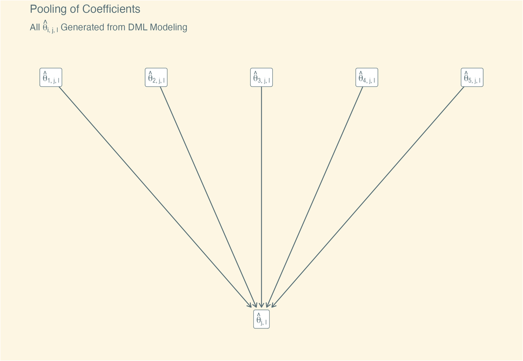

Figure 6: Pooling Flowchart. Note that $\hat{\theta}_{j,l}$ is the mean of all $\hat{\theta}_{i,j,l}$.

## 3 Results

### 3.1 General Remarks

In the interest of efficiency, I now preface my results by elaborating on the final design choices common to multiple chapters. These follow mainly from theoretical considerations, encompassing (1.) covariate selection, (2.) fixed effects, (3.) regional model variants, and (4.) interaction-term treatments.

#### 3.1.1 Covariates

In Section 2.2.1.2, I enumerated the covariates featured in all three chapters. My rationale for their inclusion may be summarized as follows:

1. Accession to PTAs/BITs and exposure to economic sanctions may correlate with quality of democratic institutions. Hypotheses for these possible relationships include:
   1. Democracies, being intrinsically more prone to complying with human-rights standards and the accords enshrining them, may have fewer qualms about agreeing to hard PTAs in the first place (Spilker & Böhmelt, 2013, p. 352).
   2. States with poor democratic institutions may be motivated to improve their credibility among foreign investors and thus seek membership in more BITs.[^165]
   3. States with poor (or decaying) democratic institutions are naturally more vulnerable to becoming targets of those sanctions expressly intended to improve democracy and human-rights respect (Peez, 2025, p. 16).

   The democracy scores I employ are ultimately meant to control for these scenarios. To avoid privileging a single conceptualization or measure of democracy, a typical practice in the underlying literature,[^166] I select all 26 of V-Dem’s high- and mid-level indices. Importantly, I ignore the far-more numerous lower-level V-Dem indicators to contain computational expenses, and since many of these are aggregated into (and thus captured by) the mid- and high-level indices in any case.
2. In a similar vein, I also include Polity and Regime Durability. Polity serves as the proxy for democracy in the PTAs/BITs literature, so its inclusion helps clarify comparability with the works thereof. Regime Durability—the number of years since the last major, structural change in a state’s regime[^167]—performs a similar function, since it figures in these pieces as well. However, it may also be seen as capturing the recency of “trigger events,”[^168] which precipitate meaningful changes to institutional quality and hence susceptibility to PTA/BIT accession or economic sanctions. For example, young democracies may consent to harder PTAs to “signal their commitment” to more robust human-rights standards (Spilker & Böhmelt, 2013, p. 352). Alternatively, the proximate causes of economic sanctions may lie in sudden, unignorable instances of repression or backsliding.
3. The PTAs/BITs literature conditions on a set of World Development Indicators (WDIs) that generally includes:
   1. Trade openness—i.e., the sum of exports and imports of goods and services as a percentage of GDP. The literature adduces research finding that flows of international commerce may influence human-rights respect, for better or worse.[^169] Although correlations with the treatment(s) are not explicitly theorized, one may plausibly expect trade-favoring states to exhibit commensurate sympathy to liberal economic treaties, including PTAs and BITs.
   2. Foreign direct investment (FDI). Hafner-Burton’s (2005) measure sums the absolute values of net FDI inflows and outflows (p. 617), whereas Bodea & Ye (2020) focus on the inflows component (p. 965).[^170] In either case, the foregoing hypothesis linking international economic transactions and human-rights respect motivates their inclusion. However, it is likewise natural to intuit that openness to FDI correlates with agreeability to treaties such as PTAs and BITs.
   3. Population density (per square kilometer). Explaining its inclusion, Hafner-Burton (2005, p. 617) and Spilker & Böhment (2013, p. 351) point to scholarship raising concerns about population pressure driving resource scarcity and hence higher rates of repression. If population density affects human-rights respect in this way, however, then it would be logical to anticipate a similar link to democracy, a possible determinant of PTA/BIT membership (for reasons aforementioned).

   Peez (2025) does not use any of these covariates. Yet it seems plausible that sanctions senders might be warier of targeting countries better-integrated into the global economy, lest doing so disrupt (directly or indirectly) critical transactional flows, harming their own economies in the process. Conversely, economically-isolated (or “-weak”) states—mattering less to the economies of sender states—may be more vulnerable to sanctions. Targets’ economic importance, captured by signals such as trade openness and FDI inflows/outflows, may thus be fairly suspected as a confounding factor. Moreover, any relationship between population density and democracy would naturally have implications for economic-sanctions vulnerability.

   The group of WDIs initially used in the PTAs/BITs literature therefore seems appropriate for the entire dissertation. For the most part, I utilize consistent, untransformed versions of the WDIs, the only exception being the FDI metrics. Specifically, in Chapter 1, I recreate the single measure of FDI in Hafner-Burton (2005), thus ensuring direct comparability thereto. In Chapter 2, on the other hand, I generally follow Bodea & Ye’s (2020) approach, including both the inflows and outflows components as separate regressors under the assumption that the latter may also influence amenability to BITs.[^171] This design choice is repeated for Chapter 3, since I prefer the safety of variables in their original form wherever possible.
4. Gross domestic product per capita (GDPpc)—a proxy for national wealth—is put to work throughout the underlying literature. In the PTAs/BITs articles, GDPpc controls for the link between poverty and repression (Hafner-Burton, 2005, p. 617; Spilker & Böhmelt, p. 352); however, it is also reasonable to postulate a connection between wealth and PTA/BIT membership. Specifically, rich states may look to PTAs/BITs as a means of guaranteeing or locking in favorable market conditions, whereas poorer states may do so aiming for improved market access and accelerated development. Peez (2025), by contrast, rationalizes the use of GDPpc on a potential link to treatment assignment, theorizing that economically “weak” states may be more vulnerable to becoming sanctions targets (p. 14). Regardless, the possible confoundedness (explicitly or implicitly) motivating GDPpc’s use as a common covariate seems sufficiently credible to warrant its continued inclusion in my own models.

   The relevant literature do not deploy gross domestic product (GDP) or population as controls. However, an effect on treatment assignment by present or future market size—for which GDP and population serve as proxies—needs little to entertain. First, the same dynamics pushing wealthy or poor states to join PTAs/BITs may well apply, respectively, to large or small states, who may seek out such treaties to lock in economic predominance or jumpstart growth. Also, large-market states may enjoy greater insulation from sanctions than small-market states, whose current or projected contributions to the global economy may be registered as less significant in the cost-benefit analyses of sanctions senders. Therefore, there exists adequate reason to incorporate GDP and population as controls throughout, too.[^172]

   The exact variables I choose are Fariss et al.’s (2022). Generated from a latent-variable model drawing on myriad measurements of GDP, GDPpc, and population, their own estimates are designed to provide enhanced measurement coverage, certainty, and resistance to bias than any of their model’s individual inputs.[^173] As such, these measures are likely safer than those that do not (e.g., the WDIs for GDP, GDPpc, and population, which also form a share of the foregoing inputs), making them worthy for inclusion in models such as mine.
5. The final batch of predictors I invariably implement endeavors to account for impacts occasioned by the threat or onset of financial crises. A diversity of observers—including international organizations (e.g., the United Nations), watchdogs (e.g., Amnesty International), and more—have cast financial crises as a major catalyst of repression (Mukherjee & Yadav, 2024, pp. 16-17). The story typically told for this causal link is straightforward: financial crises, whose ramifications are wide-ranging and devastating, compel many disaffected citizens to mobilize against their governments, who in turn greet their dissent with repression.[^174] Mukherjee & Yadav (2024) complicate this image by pointing out that while it does not “inevitably” follow, as traditional accounts would have it (p. 17), repression is indeed a possible outcome of financial crises, particularly amid a “twin” currency and sudden-stop crisis and International Monetary Fund (IMF) program participation.[^175] In any case, the literature agrees that a correlation between financial crises and repression is to be expected in at least some cases, raising the possibility of its role as a confounder in my modeling.

   Currency crises and sudden stops—the foci of Mukherjee & Yadav’s (2024) study—are especially important to consider. The proximate cause of the former are usually speculative attacks by foreign-exchange traders. Though the conditions undergirding and triggers of these attacks have been elaborated by multiple “generations” of research, their upshot is the same: depletion of foreign-currency reserves (e.g., U.S. dollars) and galloping domestic-currency depreciation.[^176] Similarly, though ascribed to a variety of sources in the literature, sudden-stop crises all share the same basic pattern: a dramatic retraction of capital inflows (e.g., foreign-portfolio investment), undercutting national outputs and foreign-currency reserves in turn. In this way, sudden stops may effectuate or contribute to currency crises themselves.[^177] To avert, ameliorate, or resolve these crises, states may look to policies that improve their balance of payments (BoP) and thus rebuild their foreign-currency reserves.[^178] Of these, perhaps the most well-known is assistance from the IMF, the international “lender of last resort” (Mukherjee & Yadav, 2024, pp. 76-77). Yet it is rational to expect states to seek relief in other sources, too, including liberal trade and investment treaties. Indeed, acceding to these would in theory mitigate salient short- and long-term contributors to the financial crises at issue. In the short-term, they would lower the costs facing prospective investors and importers from foreign states, unlocking the kinds of transcations conducive to replenishing reserve currencies. Additionally, they would signal commitment to macroeconomic stability, encouraging such transactions still further. In the long-term, these benefits would compound, fueling a virtuous cycle marginalizing the specter of financial-crisis outbreak. That states follow this logic is even supported anecdotally: negotiations for a [free trade agreement between Sri Lanka and Thailand](https://investmentpolicy.unctad.org/international-investment-agreements/treaties/bit/5136/sri-lanka---thailand-fta-2024-) were accelerated in 2023, and concluded the following year, expressly to help the former rebuild its foreign-currency reserves amid its own financial crisis.[^179] Therefore, the clear implication is that currency and sudden-stop crises might well be confounders in chapters 1 and 2, increasing not only the likelihood of repression, but also PTAs/BITs accession. Although these crises may not directly trigger sanctions, their deleterious impact on democratic institutions may heighten vulnerability thereto, rendering financial crises a possible confounder in Chapter 3 as well.[^180]

   Controlling for currency and sudden-stop crises is mostly simple to achieve by dint of publicly-available sources. Specifically, although Mukherjee & Yadav’s (2024) replication data are as yet unpublished, to the best of my knowledge, versions of the variables cited as informing their own are easy to locate. First, Nguyen et al. (2022) provide an updated version of the Laeven & Valencia (2020) Systemic Banking Crises Database, a comprehensive tracker of several financial-crisis types, including currency crises.[^181] Most helpfully, Nguyen et al.’s (2022) dataset is rendered in country-year panel format, thereby offering a currency-crisis indicator ready for use in models such as mine. Unfortunately, none of these datasets contain an indicator for sudden-stop crises, specifically, and the sources Mukherjee & Yadav (2024, p. 152) adduce for constructing theirs exhibit poor coverage.[^182] However, because sudden stops become currency crises when sufficiently severe (Nguyen et al., 2022, p. 3), sudden-stop crises frequenly coincide with currency crises; and indeed, in Mukherjee & Yadav’s (2024) sample of developing countries, the two co-occured approximately two-thirds of the time (p. 14). Consequently, following Nguyen et al. (2022), who aver that a sudden-stop crisis “can be identified through a currency crisis” (p. 3), I proceed with their currency-crisis indicator alone, presupposing that it suffices to capture sudden-stop crises as well.

   To model the possible link between IMF program participation and financial-crisis onset—and, ergo, PTAs/BITs accession or financial-sanctions imposition—I also incorporate a 2023 update to Vreeland’s (2007) indicator, which simply registers whether a country was party to any IMF arrangement during a given year.[^183] Though applying a somewhat-different taxonomy of eligible arrangements to form their own indicator, Mukherjee & Yadav (2024) cite his original dataset as a source (pp. 154-155), making Vreeland’s indicator a credible alternative thereto. Finally, it is possible that states seek to adopt some liberal economic policies—including PTAs/BITs and those attending IMF programs—to improve their BoP in preemption of a full-bore crisis. Therefore, to capture the relative “health” of a state’s BoP, which may figure prominently in their projections and calculi, I include BoP as a percentage of GDP. To create this variable, I simply take the BoP figures provided by the IMF and divide them by an unscaled version of Fariss et al.’s (2022) GDP estimates.[^184]

<sup>165</sup> Bodea & Ye (2020) describe this theory but conclude that the evidence supporting it is “weak” (p. 957). Still, including democracy scores is sensible lest their view be incorrect.

<sup>166</sup> Namely, Hafner-Burton (2005), Spilker & Böhmelt (2013), and Bodea & Ye (2020) use Polity, whereas Peez (2025) leverages V-Dem’s Polyarchy.

<sup>167</sup> Formally, the variable represents the number of years since the last occurrence of a three-point movement or greater (within a span of three years or fewer) on the Polity scale. For more, see the [QoG Codebook](https://www.gu.se/en/quality-government/our-research/publications/codebooks).

<sup>168</sup> This term is borrowed from Peez (2025), who centers such events in his theorizing and modeling.

<sup>169</sup> See Hafner-Burton (2005, p. 617) and Spilker & Böhmelt (2013, p. 352) for more.

<sup>170</sup> Spilker & Böhmelt (2013) decline to utilize an FDI metric, largely citing theoretical correlation with trade openness and missingness in the corresponding WDIs (p. 352). Needless to say, however, my dependence on multicollinearity-robust learners and multiple imputation alleviates these concerns.

<sup>171</sup> Indeed, following Bodea & Ye’s (2020) own logic, major FDI senders may seek out BITs to lock in friendly investment conditions for themselves.

<sup>172</sup> Technically, doing so is safest conditional on the use of multicollinearity-robust learners (such as those I employ), since GDP and population are known to covary to a high degree.

<sup>173</sup> See Fariss et al. (2022, p. 554) for a brief summary of the main benefits their estimates promise. For a complete list of their input variables, see Fariss et al. (2022, pp. 560-561).

<sup>174</sup> My characterization distills the prevailing understanding as described in Mukherjee & Yadav (2024, pp. 15-17).

<sup>175</sup> Put simply, their theory is that “shadow banks” collectively pressure IMF-program participants to renege on the conditions targeting them, prompting currency traders and foreign investors to initiate speculative attacks and withdrawals from equity markets, respectively, which in turn triggers currency and sudden-stop crises simultaneously. This scenario lowers “attribution uncertainty”—citizens are more ready to blame their governments for the twin crises—rendering dissent and therefore repression more likely. For a more complete summary, see Mukherjee & Yadav (2024, pp. 40-45). Note that the authors prefer “sudden reversal” over “sudden stop,” the term more commonly used by economists. The two are synonymous, as clarified in Mukherjee & Yadav (2024, p. 28).

<sup>176</sup> For summaries of the literature, see Nguyen et al. (2022, p. 2) and Mukherjee & Yadav (2024, pp. 27-28).

<sup>177</sup> Recapitulations of the research on sudden stops may be found in Nguyen et al. (2022, p. 3) and Mukherjee & Yadav (2024, pp. 27-28).

<sup>178</sup> The Federal Reserve Bank of St. Louis offers a useful [primer on BoP](https://www.stlouisfed.org/publications/page-one-economics/2025/oct/what-is-the-balance-of-payments). Note that “currency crises” and “balance-of-payments crises” are used interchangeably by economists owing to the fundamental problem of reserve-currency depletion. For example, see Krugman (1979).

<sup>179</sup> For more on the fast-tracking and finalization of the Sri Lanka-Thailand free trade agreement, see news articles thereon from [the AP](https://apnews.com/article/politics-thailand-sri-lanka-business-406eac1bc5932d8f77dc8a2dc4ceab77), [Reuters](https://www.reuters.com/world/asia-pacific/thailand-sri-lanka-sign-free-trade-agreement-2024-02-03/), and [Al Jazeera](https://www.aljazeera.com/news/2024/2/3/sri-lanka-signs-free-trade-deal-with-thailand-to-revive-economy), for example.

<sup>180</sup> Indeed, in some instances, financial crises have led to government collapse or instability, followed in turn by “severe political violence” (Mukherjee & Yadav, 2024, p. 24).

<sup>181</sup> For the Nguyen et al. (2022) dataset, see [Appendix A](https://www.sciencedirect.com/science/article/abs/pii/S0264999322000165) of the online article. Mukherjee & Yadav (2024, p. 154) reference the original Laeven & Valencia (2008) dataset as a contributor to the currency-crisis component of their financial-crisis indicator. However, their sample extends to the year 2015 (Mukherjee & Yadav, 2024, p. 151), rendering it likelier that they drew on one of the more recent datasets (Laeven & Valencia, 2013; 2020).

<sup>182</sup> For instance, Forbes & Warnock (2020), which updates Forbes & Warnock (2012) and contains a sudden-stop indicator, covers only 59 countries. By contrast, Nguyen et al. (2022) cover 211 countries. For more on their limited coverage, see Forbes & Warnock (2020, p. 4).

<sup>183</sup> For the dataset and codebook, see Vreeland’s webpage for [IMF Arrangements Data](https://vreeland.scholar.princeton.edu/imf-arrangements-data).

<sup>184</sup> Technically, I source the the BoP data directly from the [World Bank](https://data360.worldbank.org/en/prosperity), which allows accessible downloading of the IMF data.

#### 3.1.3 Regional Models

#### 3.1.4 Interactions

As treatments (alongside regular treatments).

### 3.2 Chapter 1: PTAs

#### 3.2.1 Treatments

#### 3.2.2 Covariates

#### 3.2.3 Replication: Hafner-Burton (2005)

#### 3.2.4 Findings

### 3.3 Chapter 2: BITs

#### 3.3.1 Treatments

#### 3.3.2 Covariates

#### 3.3.3 Replication: Bodea & Ye (2020)

#### 3.3.4 Findings

### 3.4 Chapter 3: Economic Sanctions

#### 3.4.1 Treatments

#### 3.4.2 Covariates

#### 3.4.3 Replication: Peez (2025)

#### 3.4.4 Findings

## 4 Conclusion

Weakness of DML: exposed to criticism of “black box.” Advantages: …

Collaboration between quantitative and qualitative scholars (former can identify or confirm causality, latter can describe causality.)

Bring multiple imputation & DML literature into further conversation. Former typically assumes n > p, but DML considers p > n.

## 5 Bibliography

Ahrens, A., Chernozhukov, V., Hansen, C., Kozbur, D., Schaffer, M., & Wiemann, T. (2025). An Introduction to Double/Debiased Machine Learning (Version 1). arXiv. https://doi.org/10.48550/ARXIV.2504.08324

Bach, P., Kurz, M. S., Chernozhukov, V., Spindler, M., & Klaassen, S. (2024). DoubleML: An Object-Oriented Implementation of Double Machine Learning in R. Journal of Statistical Software, 108(3). https://doi.org/10.18637/jss.v108.i03

Chernozhukov, V., Chetverikov, D., Demirer, M., Duflo, E., Hansen, C., Newey, W., & Robins, J. (2018). Double/debiased machine learning for treatment and structural parameters. The Econometrics Journal, 21(1), C1–C68. https://doi.org/10.1111/ectj.12097

Chernozhukov, V., Hansen, C., Kallus, N., Spindler, M., & Syrgkanis, V. (2024). Applied Causal Inference Powered by ML and AI (No. arXiv:2403.02467). arXiv. https://doi.org/10.48550/arXiv.2403.02467

Hastie, T., Tibshirani, R., & Wainwright, M. (2015). Statistical Learning with Sparsity: The Lasso and Generalizations. CRC Press, Taylor & Francis Group.

Hastie, T., Friedman, J., & Tisbshirani, R. (2017). The Elements of Statistical Learning: Data Mining, Inference, and Prediction, Second Edition (2nd ed.). Springer. https://doi.org/10.1007/978-0-387-84858-7

Zou, H., & Hastie, T. (2005). Regularization and Variable Selection Via the Elastic Net. Journal of the Royal Statistical Society Series B: Statistical Methodology, 67(2), 301–320. https://doi.org/10.1111/j.1467-9868.2005.00503.x

## 6 Appendices

### 6.1 Appendix A: Excluded Countries

[figure not shown]

Figure 7: Table of Countries Excluded from Models

### 6.2 Appendix B: Countries Coded Manually

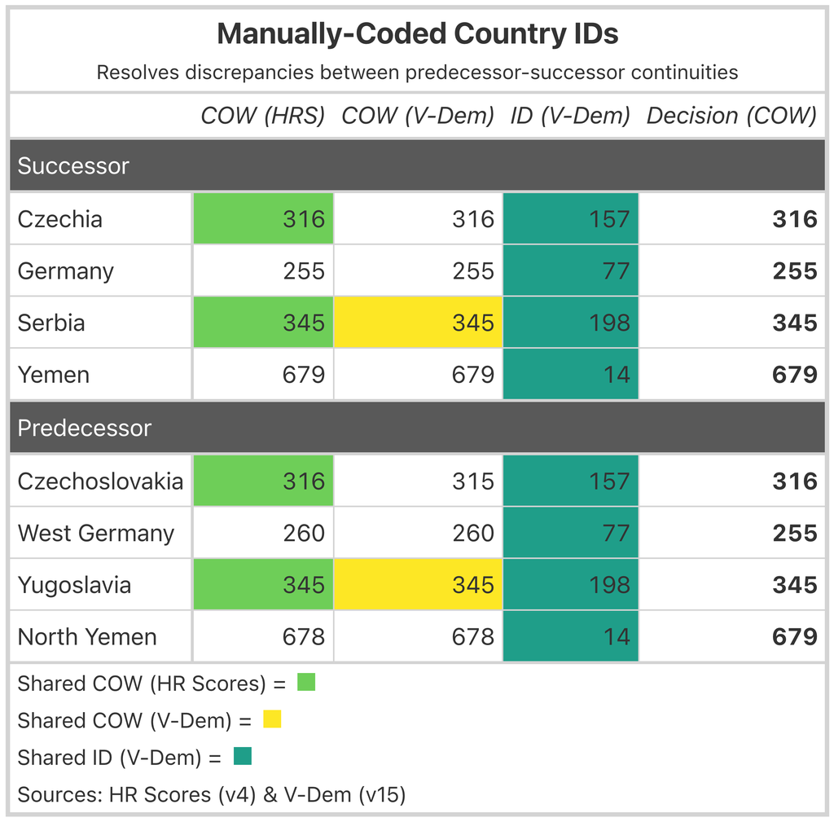

Figure 8: Table of Manually-Coded Country IDs

### 6.3 Appendix C: Country Totals

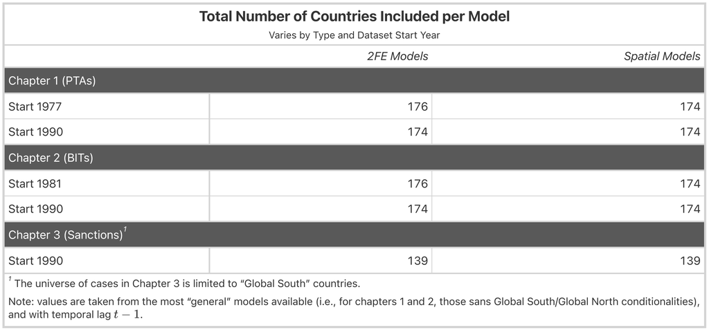

Figure 9: Table of Total Country Counts per Model

### 6.4 Appendix D: Missingness Summaries

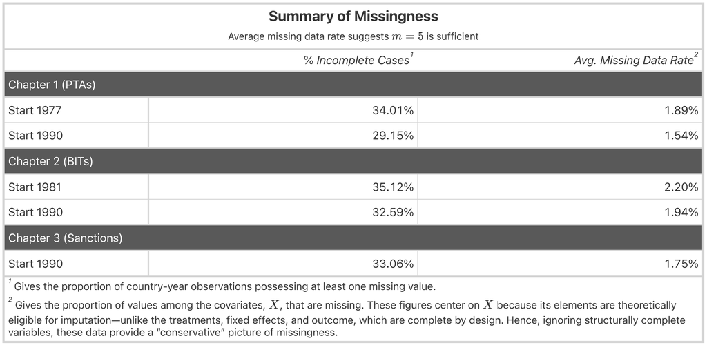

Figure 10: Table Summarizing Missingness

### 6.5 Appendix E: PLR Score Function to OLS

Recall from Section 2.3.3 that the generic DML estimator solves the moment condition:

$$\begin{align*}
\frac{1}{n}\sum_{i \in I}\psi(\mathbf{S};\hat{\theta}_{0},\hat{\eta}_{0}) = 0
\end{align*}$$

Also recall the standard PLR score function, which may be further expanded:

$$\begin{align*}
\psi(\mathbf{S};\theta,\eta) := [\mathbf{Y} - \ell(\mathbf{X}) - \theta(\mathbf{D} - m(\mathbf{X}))][\mathbf{D} - m(\mathbf{X})]\ \\
= -\theta(\mathbf{D} - m(\mathbf{X}))^{2} + (\mathbf{Y} - \ell(\mathbf{X}))(\mathbf{D} - m(\mathbf{X}))
\end{align*}$$

Solving the moment-condition estimator gives:[^185]

<sup>185</sup> The distribution of the mean operator $\left(\frac{1}{n}\sum_{i \in I}\right)$ and the constant ($-\hat{\theta}$) follows from the linearity of expectation.

$$\begin{align*}
0 = \frac{1}{n}\sum_{i \in I}[-\hat{\theta}_{0}(\mathbf{D} - \hat{m}(\mathbf{X}))^{2} + (\mathbf{Y} - \hat{\ell}(\mathbf{X}))(\mathbf{D} - \hat{m}(\mathbf{X}))] \\
\Longrightarrow 0 = -\hat{\theta}_{0}\frac{1}{n}\sum_{i \in I}(\mathbf{D} - \hat{m}(\mathbf{X}))^{2} + \frac{1}{n}\sum_{i \in I}(\mathbf{Y} - \hat{\ell}(\mathbf{X}))(\mathbf{D} - \hat{m}(\mathbf{X})) \\
\Longrightarrow \hat{\theta}_{0}\frac{1}{n}\sum_{i \in I}(\mathbf{D} - \hat{m}(\mathbf{X}))^{2} = \frac{1}{n}\sum_{i \in I}(\mathbf{Y} - \hat{\ell}(\mathbf{X}))(\mathbf{D} - \hat{m}(\mathbf{X})) \\
\Longrightarrow \hat{\theta}_{0} = \frac{\sum_{i \in I}(\mathbf{Y} - \hat{\ell}(\mathbf{X}))(\mathbf{D} - \hat{m}(\mathbf{X}))}{\sum_{i \in I} (\mathbf{D} - \hat{m}(\mathbf{X}))^{2}}
\end{align*}$$

Where:

$$\begin{align*}
\mathbf{\hat{Q}} = \mathbf{Y} - \hat{\ell}_{0}(\mathbf{X}) \\
\mathbf{\hat{V}} = \mathbf{D} - \hat{m}_{0}(\mathbf{X})
\end{align*}$$

And where $\hat{\ell}_{0}$ and $\hat{m}_{0}$ are plug-in estimators of the conditional expectations:

$$\begin{align*}
\ell_{0}(\mathbf{X}) = \mathbb{E}[\mathbf{Y}|\mathbf{X}] \\
m_{0}(\mathbf{X}) = \mathbb{E}[\mathbf{D}|\mathbf{X}]
\end{align*}$$

Now, consider a simple linear regression, wherein OLS predicts an outcome $\mathbf{Y}$ from a single treatment $\mathbf{D}$.[^186] The true coefficient on the explanator may be expressed as:[^187]

<sup>186</sup> To wit: $\mathbf{Y} = \beta_{0} + \beta_{1}\mathbf{D} + \epsilon_{i}$

<sup>187</sup> That is, $\beta_{1} = \frac{\text{Cov}(\mathbf{D}, \mathbf{Y})}{\text{Var}(\mathbf{D})}$. In the bivariate case, $\mathbb{E}[\mathbf{D}] = \bar{\mathbf{D}}$ and $\mathbb{E}[\mathbf{Y}] = \bar{\mathbf{Y}}$. The basic formula may be found in Rice (2007, p. 544), for example, albeit in scalar notation.

$$\begin{align*}
\beta_{1} = \frac{\sum_{i \in I}(\mathbf{Y} - \mathbb{E}[\mathbf{Y}])(\mathbf{D} - \mathbb{E}[\mathbf{D}])}{\sum_{i \in I} (\mathbf{D} - \mathbb{E}[\mathbf{D}])^{2}}
\end{align*}$$

Or, in the multivariate case, with covariates $\mathbf{X}$, regressing residualized $\mathbf{Y}$ on residualized $\mathbf{D}$ implies (as per the FWL Theorem):

$$\begin{align*}
\beta_{1} = \frac{\sum_{i \in I}(\mathbf{Y} - \mathbb{E}[\mathbf{Y|X}])(\mathbf{D} - \mathbb{E}[\mathbf{D|X}])}{\sum_{i \in I} (\mathbf{D} - \mathbb{E}[\mathbf{D|X}])^{2}} \\
= \frac{\sum_{i \in I}(\mathbf{Y} - \ell_{0}(\mathbf{X}))(\mathbf{D} - m_{0}(\mathbf{X}))}{\sum_{i \in I} (\mathbf{D} - m_{0}(\mathbf{X}))^{2}}
\end{align*}$$

The solutions to $\hat{\theta}_{0}$ and the sample analogue $\hat{\beta}_{1}$ of $\beta_{1}$ are thus the selfsame, sufficing to illustrate how partialling out—that is, regressing $\mathbf{\hat{Q}}$ on $\mathbf{\hat{V}}$ to obtain $\hat{\theta}_{0}$ using OLS—implies the standard PLR score function.

### 6.6 Appendix F: Example of Cluster-Robust DML Resampling

To better-illustrate the resampling procedure introduced in Section 2.3.5.3, consider a basic panel dataset comprised of countries $c \in [C] = \{1, ..., C\}$ and years $t \in [T] = \{1, ..., T\}$.[^188] In addition, let $C = 4$, $T = 4$, and $K = 2$. Now, suppose that the $C$ countries and $T$ years are randomly partitioned into the following initial subgroups:

<sup>188</sup> Recalling the notation used in Section 2.3.5.3, $C$ equates to $N$ and $T$ to $M$.

$$\begin{align*}
I_{1} = \{c_{1}, c_{3}\} \qquad J_{1} = \{t_{2}, t_{3}\} \\
I_{2} = \{c_{2}, c_{4}\} \qquad J_{2} = \{t_{1}, t_{4}\}
\end{align*}$$

Per the two-way splitting operation, these form $K^{2} = 4$ folds:

$$\begin{align*}
I_{1} \times J_{1} = \{(c_{1},t_{2}), (c_{1},t_{3}), (c_{3},t_{2}), (c_{3},t_{3})\} \\
I_{1} \times J_{2} = \{(c_{1},t_{1}), (c_{1},t_{4}), (c_{3},t_{1}), (c_{3},t_{4}\}) \\
I_{2} \times J_{1} = \{(c_{2},t_{2}), (c_{2},t_{3}), (c_{4},t_{2}), (c_{4},t_{3})\} \\
I_{2} \times J_{2} = \{(c_{2},t_{1}), (c_{2},t_{4}), (c_{4},t_{1}), (c_{4},t_{4})\}
\end{align*}$$

Each is treated once as a test set, evaluating fits from corresponding training sets:

$$\begin{align*}
I_{1}^{c} \times J_{1}^{c} = I_{2} \times J_{2} \\
I_{1}^{c} \times J_{2}^{c} = I_{2} \times J_{1} \\
I_{2}^{c} \times J_{1}^{c} = I_{1} \times J_{2} \\
I_{2}^{c} \times J_{2}^{c} = I_{1} \times J_{1}
\end{align*}$$

How cluster-robust cross-fitting compares to the conventional approach summarized in Section 2.3.3 is therefore clear. On the one hand, both guarantee observation-wise mutual exclusivity, guarding against the severest type of data leakage: observations appearing on both sides of the same training-test set pair. On the other, cluster-robust cross-fitting goes a step further, enforcing group-wise independence as well. This is achieved by forming training sets from only those observations disjoint from the test set on all specified dimensions (e.g., country and year). Consequently, in the multiway case, these training sets are invariably smaller than those that would be formed under conventional sample splitting, whereby all observations not belonging to the test set simply constitute the training set.